# BIOVEG - Statistical analyses in R

#### GNM (Generalized Nonlinear Models)

If you find significant non-linear relationships among variables, you can first try transforming (e.g. log, square) the predictor variable. This will not always be enough to resolve non-linearity issues and it can turn p-values of the linearity tests non-significant. If non-linearity is not resolved using this procedure, models such as LM, GLM and GLS are not the appropriate model for this purpose. Indeed, a better way to deal with non-linearity may be to apply a model that uses a nonlinear function of the predictor variables, i.e. on the right-hand side of the model formula. GNM models still require you to specify the distribution family of the dependent variable (e.g. Gaussian, Poisson, Quasi-poisson). Furthermore, it is possible to use an option to coerce a GLM model to a GNM model, as explained at the end of this section.

If the relationship between some of the predictor and the dependent variables is nonlinear, is necessary to use a proper model that accounts for the nonlinear effects.

```r
BIOVEG <- read.table("BIOVEG3.csv", header=T, sep=",", dec=".")
head(BIOVEG,4)
```

```
##           type Plot  Site                Species Richness Diameter
## 1 Semidecidual p001 AREA1 Alchornea_triplinervia        8    27.12
## 2 Semidecidual p002 AREA1     Amaioua_intermedia       10    39.15
## 3 Semidecidual p003 AREA1          Aniba_firmula       10    33.93
## 4 Semidecidual p004 AREA1          Annona_cacans       10    40.43
##   Mean_diameter Basal.area Abundance Precipitation_mean Temperature_mean
## 1         6.357      0.058         7               1250             24.4
## 2         6.524      0.120        12               1250             24.4
## 3         6.632      0.090        10               1250             24.4
## 4         6.626      0.128        19               1250             24.4
##   Mortality Recruitment local.x local.y  utm.x   utm.y local.utm.x
## 1      6.94       14.34       0       0 747923 7807727      747923
## 2      2.74        6.94     -10       0 747923 7807727      747913
## 3      1.71        2.35     -20       0 747923 7807727      747903
## 4      1.60        2.47     -30       0 747923 7807727      747893
##   local.utm.y
## 1     7807727
## 2     7807727
## 3     7807727
## 4     7807727
```

```r
## Base LM model to apply linearity test

Abundance.pre <- lm(Abundance ~ Recruitment, data=BIOVEG)
summary(Abundance.pre)
```

```
##
## Call:
## lm(formula = Abundance ~ Recruitment, data = BIOVEG)
##
## Residuals:
##     Min      1Q  Median      3Q     Max
## -17.110  -9.205  -2.062   8.069  37.590
##
## Coefficients:
##             Estimate Std. Error t value Pr(>|t|)
## (Intercept)  22.5720     1.3076  17.262   <2e-16 ***
## Recruitment  -0.1530     0.3819  -0.401    0.689
## ---
## Signif. codes:  0 '***' 0.001 '**' 0.01 '*' 0.05 '.' 0.1 ' ' 1
##
## Residual standard error: 10.85 on 148 degrees of freedom
## Multiple R-squared:  0.001083,   Adjusted R-squared:  -0.005667
## F-statistic: 0.1604 on 1 and 148 DF,  p-value: 0.6894
```

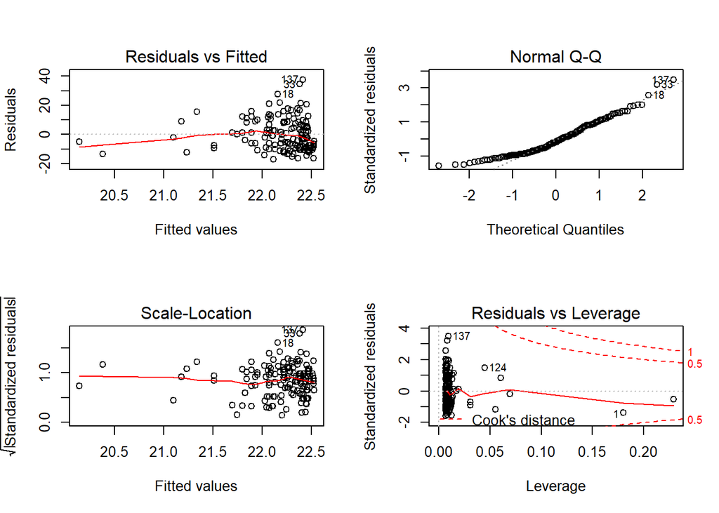

```r
## Residuals

x11(width=12, height=12)
par(mfrow=c(2,2))
plot(Abundance.pre)
```

```r
# dev.off() ## turn off the graphics device
```

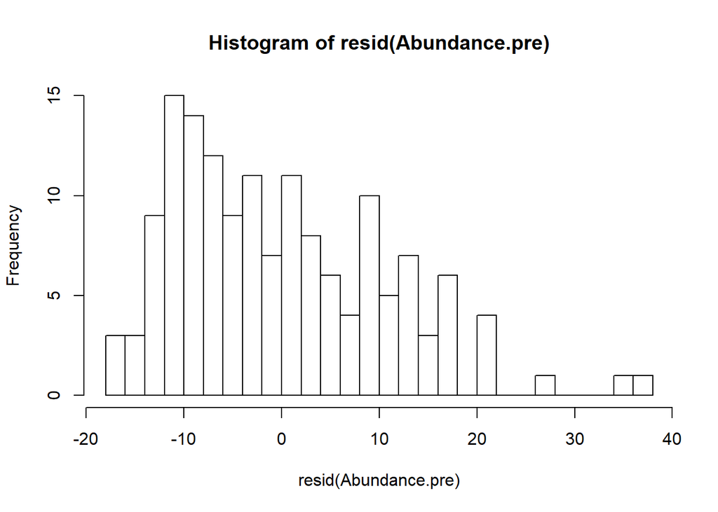

```r
hist(resid(Abundance.pre),breaks=20)
```

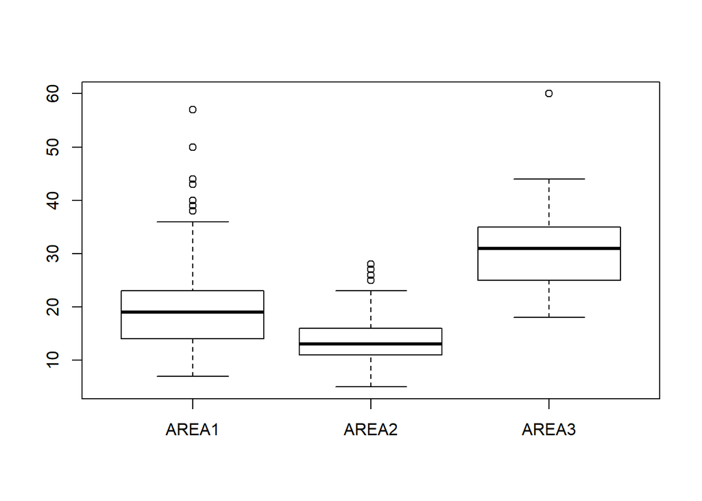

```r
# dev.off() ## turn off the graphics device
plot(BIOVEG$Site, BIOVEG$Abundance) # variation among sites
```

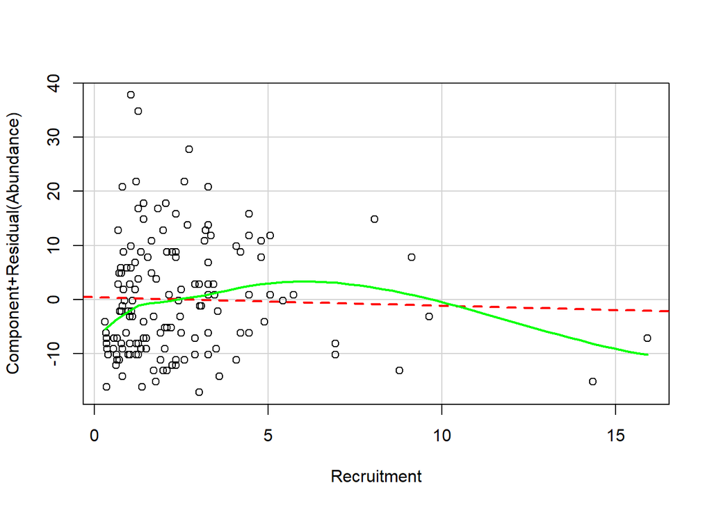

```r
### Tests of linearity

library(car)

crPlots(Abundance.pre, col.lines=c("red", "green"))
```

If one find some nonlinear relationship between predictor and dependent variable using the diagnostic for linearity showed previously here, thus a model that account for nonlinear terms is necessary to carry the statistical prediction.

#### GNM model

```r
# install.packages("gnm")
library(gnm)


Exp <- function(expression, inst = NULL){list(predictors = list(substitute
(expression)), term = function(predictors, ...) {paste("exp(", predictors, ")",
                   sep = "")}, call = as.expression(match.call()), match = 1)}
class(Exp) <- "nonlin"


N.gnm<- gnm(Abundance ~ Exp(Recruitment), data=BIOVEG, method = "gnmFit",
start = NULL, checkLinear = TRUE, verbose = FALSE, family="quasipoisson")

summary(N.gnm)
```

```
##
## Call:
##
## gnm(formula = Abundance ~ Exp(Recruitment), family = "quasipoisson",
##     data = BIOVEG, method = "gnmFit", checkLinear = TRUE, start = NULL,
##     verbose = FALSE)
##
## Deviance Residuals:
##     Min       1Q   Median       3Q      Max
## -4.4003  -2.1178  -0.4718   1.6239   6.5653
##
## Coefficients:
##                     Estimate Std. Error t value Pr(>|t|)
## (Intercept)         2.114609   0.060506  34.949   <2e-16 ***
## Exp(.).Recruitment -0.006124   0.018796  -0.326    0.745
## ---
## Signif. codes:  0 '***' 0.001 '**' 0.01 '*' 0.05 '.' 0.1 ' ' 1
##
## (Dispersion parameter for quasipoisson family taken to be 5.297747)
##
## Residual deviance: 758.18 on 148 degrees of freedom
## AIC: NA
##
## Number of iterations: 11
```

```r
An <- anova(N.gnm, test = "F")
An
```

```
## Analysis of Deviance Table
##
## Model: quasipoisson, link: log
##
## Response: Abundance
##
## Terms added sequentially (first to last)
##
##
##                  Df Deviance Resid. Df Resid. Dev      F Pr(>F)
## NULL                               149     758.90
## Exp(Recruitment)  1  0.72765       148     758.18 0.1374 0.7115
```

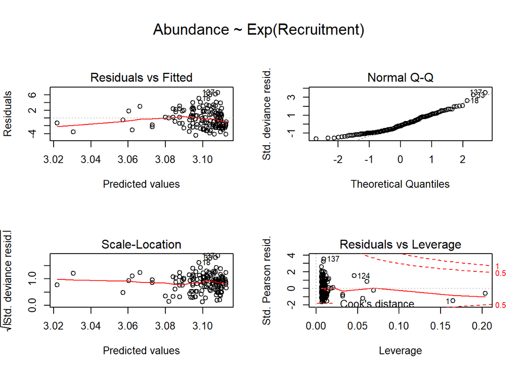

```r
## Residuals

x11(width=12, height=12)
par(mfrow = c(2,2), oma = c(0, 0, 3, 0))
title <- paste(deparse(N.gnm$formula, width.cutoff = 50), collapse = "\n")
plot(N.gnm, sub.caption = title)
```

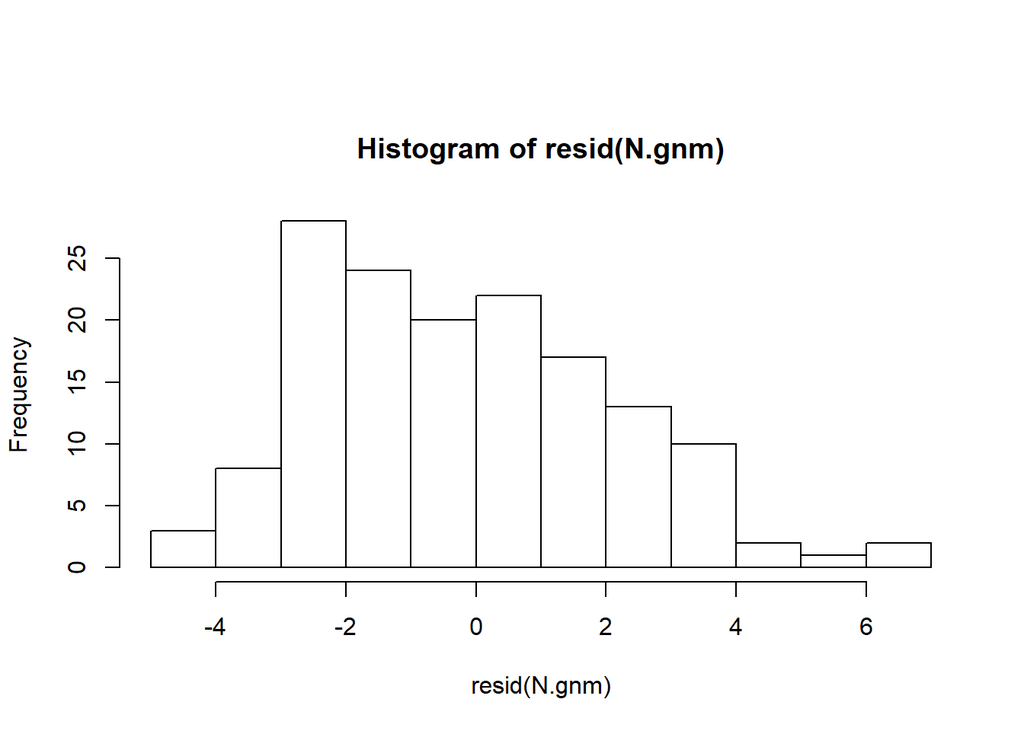

```r
par(mfrow = c(1,1))
hist(resid(N.gnm))
```

```r
## Deviance profile (optional) - just similar to a summary

prof<- profile(N.gnm, which = ofInterest(N.gnm), alpha = 0.05, trace = TRUE)
```

```
##
## Parameter: (Intercept) down
##
## Parameter: (Intercept) up
##
## Parameter: Exp(.).Recruitment down
##
## Parameter: Exp(.).Recruitment up
```

```r
prof
```

```
## $`(Intercept)`
##            z par.vals.(Intercept) par.vals.Exp(.).Recruitment
## 1 -2.8403067          1.956489865                 0.020592763
## 2 -2.1157987          1.996019735                 0.015066411
## 3 -1.3995735          2.035549606                 0.008855134
## 4 -0.6935907          2.075079476                 0.001838985
## 5  0.0000000          2.114609347                -0.006123601
## 6  0.6788683          2.154139217                -0.015198814
## 7  1.3405280          2.193669087                -0.025580767
## 8  1.9823608          2.233198958                -0.037495559
## 9  2.6016479          2.272728828                -0.051206835
##
## $`Exp(.).Recruitment`
##             z par.vals.(Intercept) par.vals.Exp(.).Recruitment
## 1  -2.6375988          2.241123006                -0.067522291
## 2  -2.2261316          2.218699500                -0.055242553
## 3  -1.7670462          2.195032431                -0.042962815
## 4  -1.2514218          2.169952883                -0.030683077
## 5  -0.6676058          2.143242552                -0.018403339
## 6   0.0000000          2.114609347                -0.006123601
## 7   0.2912929          2.102683607                -0.001272527
## 8   0.6005750          2.090364242                 0.003578548
## 9   0.9297607          2.077613861                 0.008429623
## 10  1.2810713          2.064388270                 0.013280697
## 11  1.6571012          2.050634724                 0.018131772
## 12  2.0608990          2.036289621                 0.022982846
## 13  2.4960713          2.021275416                 0.027833921
##
## attr(,"original.fit")
##
## Call:
##
## gnm(formula = Abundance ~ Exp(Recruitment), family = "quasipoisson",
##     data = BIOVEG, method = "gnmFit", checkLinear = TRUE, start = NULL,
##     verbose = FALSE)
##
## Coefficients:
##        (Intercept)  Exp(.).Recruitment
##        2.114609347        -0.006123601
##
```

[output cut: 16 more lines]

```
##                        Estimate   Std. Error  t value Pr(>|t|)
## (Intercept)         2.114609347  0.060506015 34.94875  < 2e-16 ***
## Exp(.).Recruitment -0.006123601  0.018795863 -0.32580  0.74504
## ---
## Signif. codes:  0 '***' 0.001 '**' 0.01 '*' 0.05 '.' 0.1 ' ' 1
##
## (Dispersion parameter for quasipoisson family taken to be 5.297747)
##
## Residual deviance: 758.17689 on 148 degrees of freedom
## AIC: NA
##
## Number of iterations: 11
##
## attr(,"class")
## [1] "profile.gnm" "profile.glm" "profile"
```

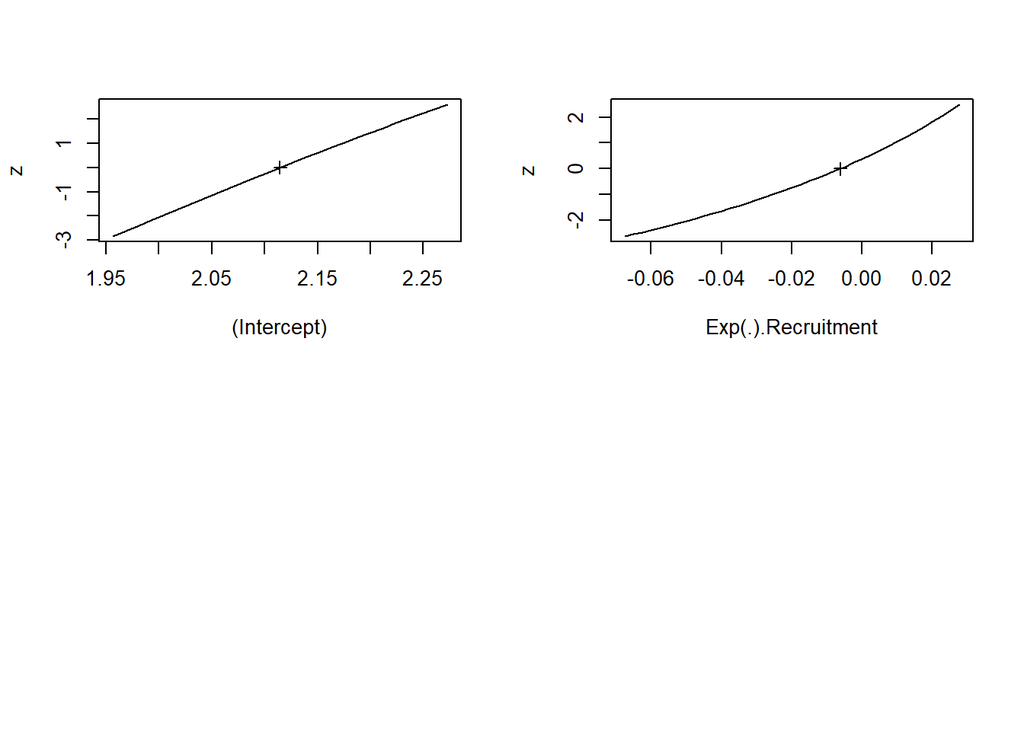

```r
x11(width=12, height=8)
plot(prof)
```

```r
# dev.off()
```

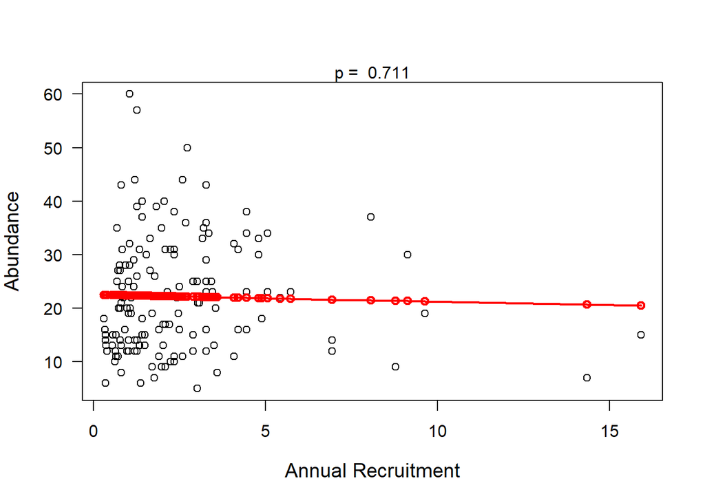

```r
## scatterplot


x11(width=12, height=12)
plot(BIOVEG$Abundance ~ BIOVEG$Recruitment, ylab="Abundance",
xlab= "Annual Recruitment", las = 1, cex.lab=1.2)
points(BIOVEG$Recruitment, fitted(N.gnm), col = "red", lwd = 2)
Smooth <- smooth.spline(BIOVEG$Recruitment, fitted(N.gnm))
lines(Smooth, col = "red", lwd = 2)
mtext(ifelse(An[2,6]<0.001, "p < 0.001", paste("p = ", round(An[2,6],3))))
```

```r
# dev.off()
```

Note 1: If you need to coerce objects of class “glm” to an object of class “gnm” follow the procedure below.

```r
Nall.glm<- glm(Abundance ~ Recruitment, data=BIOVEG, family="quasipoisson")
N.gnm2<- update(asGnm(Nall.glm))
N.gnm2
```

```
##
## Call:
## gnm(formula = Abundance ~ Recruitment, family = "quasipoisson",
##     data = BIOVEG)
##
## Coefficients:
## (Intercept)  Recruitment
##    3.117131    -0.007054
##
## Deviance:            758.0411
## Pearson chi-squared: 783.8135
## Residual df:         148
```

```r
anova(N.gnm2, test = "F")
```

```
## Analysis of Deviance Table
##
## Model: quasipoisson, link: log
##
## Response: Abundance
##
## Terms added sequentially (first to last)
##
##
##             Df Deviance Resid. Df Resid. Dev     F Pr(>F)
## NULL                          149     758.90
## Recruitment  1  0.86347       148     758.04 0.163  0.687
```

```r
summary(N.gnm2)
```

```
##
## Call:
## gnm(formula = Abundance ~ Recruitment, family = "quasipoisson",
##     data = BIOVEG)
##
## Deviance Residuals:
##    Min      1Q  Median      3Q     Max
## -4.399  -2.119  -0.451   1.632   6.557
##
## Coefficients:
##              Estimate Std. Error t value Pr(>|t|)
## (Intercept)  3.117131   0.059166  52.684   <2e-16 ***
## Recruitment -0.007054   0.017604  -0.401    0.689
## ---
## Signif. codes:  0 '***' 0.001 '**' 0.01 '*' 0.05 '.' 0.1 ' ' 1
##
## (Dispersion parameter for quasipoisson family taken to be 5.296138)
##
## Residual deviance: 758.04 on 148 degrees of freedom
## AIC: NA
##
## Number of iterations: 4
```

#### GAM (Generalized Aditive Models)

For a GAM model example, let’s assume that we only have fixed effects data(e.g. vegetation type). We will use the same variables as used for the model in a pre- test for linearity ,using the function “crPlots” of the package “car”. Since “P_mg_100g” and “K_mg_100g” demonstrated the greatest deviation from linearity, we apply a smoothing term (s) for them in the model.

```r
Hogweed <- read.table("Hogweed.csv", header=T, sep=",", dec=".")
head(Hogweed,4)
```

```
##   Plot Study.area  Habitat.type Year Veg.height Veg.cover Species.richness
## 1   s1        VOL ruderal.grass 2002        0.5        70               18
## 2   s2        VOL ruderal.grass 2002        0.7        65               19
## 3   s3        VOL ruderal.grass 2002        0.4        30               16
## 4   s4        VOL ruderal.grass 2002        0.9        90               23
##   Hogweed.height Hogweed.cover Land.use Disturbance Altitude Inclination
## 1            0.9            80     NONE   TREESHRUB  295.653           2
## 2            1.4            65     NONE   TREESHRUB  295.653           2
## 3            1.7            90     NONE   TREESHRUB  295.653           2
## 4            1.0            20     NONE        NONE  292.112           2
##   Exposition N_perc P_mg_100g K_mg_100g
## 1          W   0.19      3.99     22.27
## 2          W   0.19      3.56     12.49
## 3          W   0.19      8.44     39.95
## 4          W   0.12      2.53     12.34
```

```r
# install.packages("mgcv")
library(mgcv) # carry out GAM model

spp.gam<- gam(log(Species.richness) ~ s(P_mg_100g) + s(K_mg_100g) + Veg.cover,
                                              data=Hogweed, family="gaussian")

summary(spp.gam)
```

```
##
## Family: gaussian
## Link function: identity
##
## Formula:
## log(Species.richness) ~ s(P_mg_100g) + s(K_mg_100g) + Veg.cover
##
## Parametric coefficients:
##             Estimate Std. Error t value Pr(>|t|)
## (Intercept) 2.504829   0.075790  33.050  < 2e-16 ***
## Veg.cover   0.005250   0.001095   4.795 3.32e-06 ***
## ---
## Signif. codes:  0 '***' 0.001 '**' 0.01 '*' 0.05 '.' 0.1 ' ' 1
##
## Approximate significance of smooth terms:
##                edf Ref.df     F  p-value
## s(P_mg_100g) 5.987  6.993 3.956 0.000447 ***
## s(K_mg_100g) 7.544  8.421 2.087 0.050678 .
## ---
## Signif. codes:  0 '***' 0.001 '**' 0.01 '*' 0.05 '.' 0.1 ' ' 1
##
## R-sq.(adj) =  0.267   Deviance explained =   32%
## GCV = 0.19193  Scale est. = 0.1771    n = 201
```

In the summary, we can see two types of output: parametric coefficients, i.e., the slope of the predictor that indicated a linear relationship and was not subjected to smoothing and the non-linear predictors which were smoothed, showing their F and p-values for significance. The edf refers to the estimated degrees of freedom and basically, the larger the number, the wigglier the fitted model. Values close to 1 indicate a linear term.

```r
anova(spp.gam) # the output is quite similar to the summary
```

```
##
## Family: gaussian
## Link function: identity
##
## Formula:
## log(Species.richness) ~ s(P_mg_100g) + s(K_mg_100g) + Veg.cover
##
## Parametric Terms:
##           df  F  p-value
## Veg.cover  1 23 3.32e-06
##
## Approximate significance of smooth terms:
##                edf Ref.df     F  p-value
## s(P_mg_100g) 5.987  6.993 3.956 0.000447
## s(K_mg_100g) 7.544  8.421 2.087 0.050678
```

Below we calculate a measure for correlation (analogous to collinearity) known as concurvity, between the predictors in the model, to consider non-linear correlations. The range is from 0 to 1. The closer the value is to 1, the higher the correlation. To know more about concurvity read:

Marra, G. & Wood, S. N. Practical variable selection for generalized additive models. Comput. Stat. Data Anal. 55, 2372-2387 (2011).

```r
concurvity(spp.gam, full=FALSE)
```

```
## $worst
##                      para s(P_mg_100g) s(K_mg_100g)
## para         1.000000e+00 1.496793e-25 4.372779e-26
## s(P_mg_100g) 1.509192e-25 1.000000e+00 9.988476e-01
## s(K_mg_100g) 4.316333e-26 9.988476e-01 1.000000e+00
##
## $observed
##                      para s(P_mg_100g) s(K_mg_100g)
## para         1.000000e+00 5.574905e-28 3.880743e-27
## s(P_mg_100g) 1.509192e-25 1.000000e+00 5.477266e-01
## s(K_mg_100g) 4.316333e-26 3.313584e-01 1.000000e+00
##
## $estimate
##                      para s(P_mg_100g) s(K_mg_100g)
## para         1.000000e+00  2.91690e-28 2.149244e-28
## s(P_mg_100g) 1.509192e-25  1.00000e+00 5.080148e-01
## s(K_mg_100g) 4.316333e-26  4.49389e-01 1.000000e+00
```

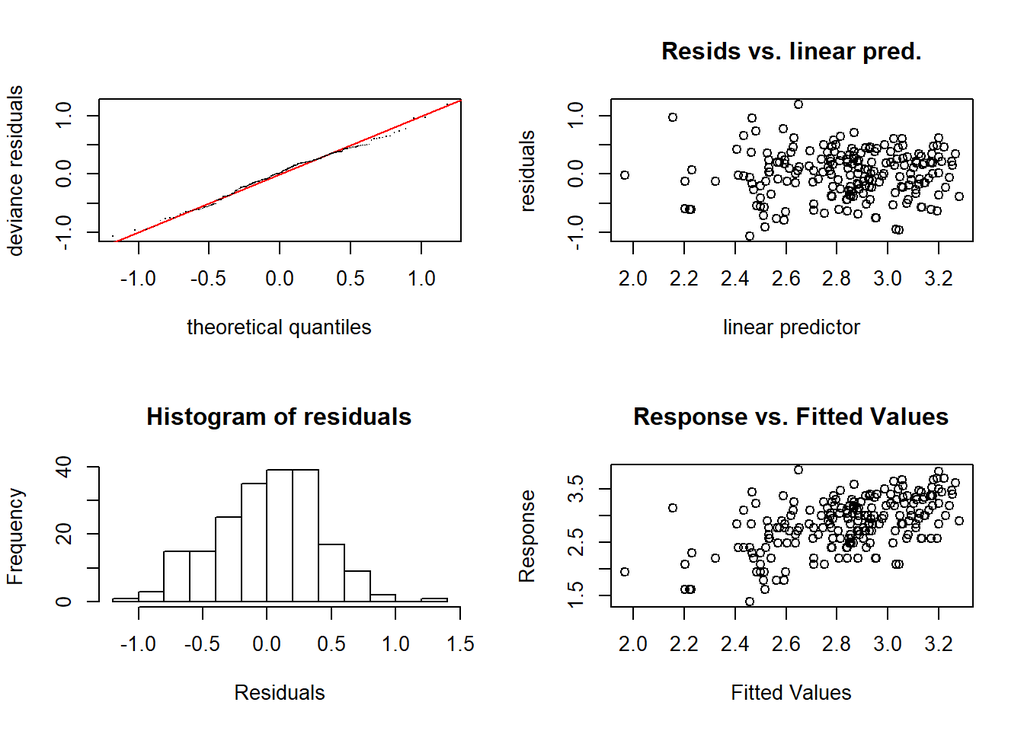

```
##
## Method: GCV   Optimizer: magic
## Smoothing parameter selection converged after 8 iterations.
## The RMS GCV score gradient at convergence was 2.668476e-06 .
## The Hessian was positive definite.
## Model rank =  20 / 20
##
## Basis dimension (k) checking results. Low p-value (k-index<1) may
## indicate that k is too low, especially if edf is close to k'.
##
##                k'  edf k-index p-value
## s(P_mg_100g) 9.00 5.99    1.09    0.85
## s(K_mg_100g) 9.00 7.54    1.14    0.99
```

```r
# Residuals

par(mfrow = c(2,2))
gam.check(spp.gam)
```

Here the graphical residuals look generally acceptable, since the histogram is not that nice (i.e. symmetrical).

Together with the graphical residuals, the model returns a written output that shows parameters for each predictor with its smoothing term e.g. “k”, “edf”, “K-index” and its p-value. “k-index” is the ratio of neighbor differencing scale estimate to fitted model scale estimate; “edf” is the previously mentioned estimated degrees of freedom and “k’” is the maximum possible EDF for the term. These parameters test whether the basis dimension for smoothing is adequate for the predictor.

For further details regarding this kind of residual diagnostic, please consult the documentation of the function “gam.check” of the package “mgcv”. One way to correctly apply a smoothing term for the predictor is to choose the most appropriate and insert it into the model using the argument “bs”. Look for “smooth.terms” in the mgcv documentation.

In order to test for improvement of the fit of the model, we included the type of smoothing with the argument “bs” and used “K” to choose the number of knots (k) once cubic regression splines have a set number of knots. The default of knots automatically defined by the model “spp.gam” was 9. Let’s test the model fit with 6 and 9 knots. Here we apply “cc” (cyclic cubic regression splines) smoothing to “bs” because of the observed tendency of non-linear fitting in a pre-diangostic graph with the function “crPLots” of package “car”. Here we test of redefine the knots for the predictor P_mg_100g because it was diagnosed as being the most non-linear, and improving its fit also may improve the overall fit of the model.

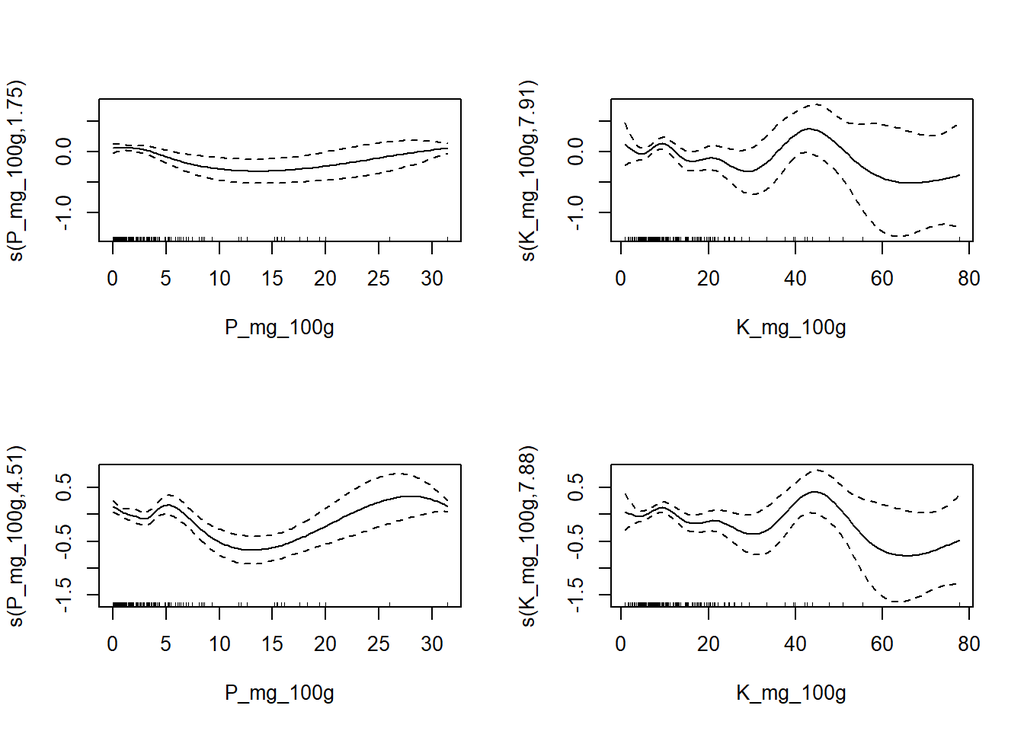

```r
par(mfrow = c(2, 2))
spp.gam2<- gam(log(Species.richness) ~ s(P_mg_100g, bs='cc', k=6) +
               s(K_mg_100g) + Veg.cover, data=Hogweed, family="gaussian")
plot(spp.gam2)
spp.gam3<- gam(log(Species.richness) ~ s(P_mg_100g, bs='cc', k=9) +
                 s(K_mg_100g) + Veg.cover, data=Hogweed, family="gaussian")
plot(spp.gam3)
```

If we still call the residuals for each model test (6 and 9 knots), the degrees of freedom (EDF) of the smoothers are close especially for the predictor “K_mg_100g” and they k-index is nonsignificant.

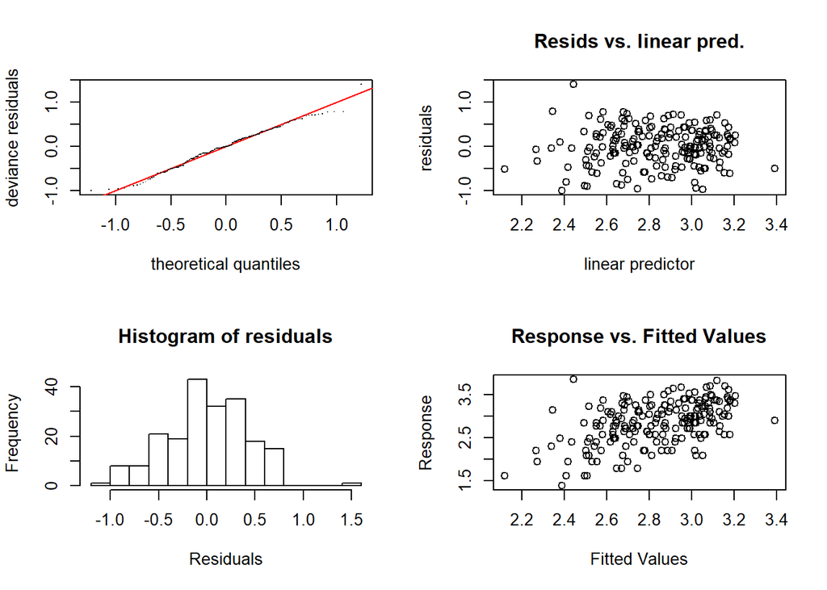

```
##
## Method: GCV   Optimizer: magic
## Smoothing parameter selection converged after 11 iterations.
## The RMS GCV score gradient at convergence was 1.500108e-07 .
## The Hessian was positive definite.
## Model rank =  15 / 15
##
## Basis dimension (k) checking results. Low p-value (k-index<1) may
## indicate that k is too low, especially if edf is close to k'.
##
##                k'  edf k-index p-value
## s(P_mg_100g) 4.00 1.75    0.99    0.43
## s(K_mg_100g) 9.00 7.91    1.18    0.99
```

```r
par(mfrow = c(2,2))
gam.check(spp.gam2)
```

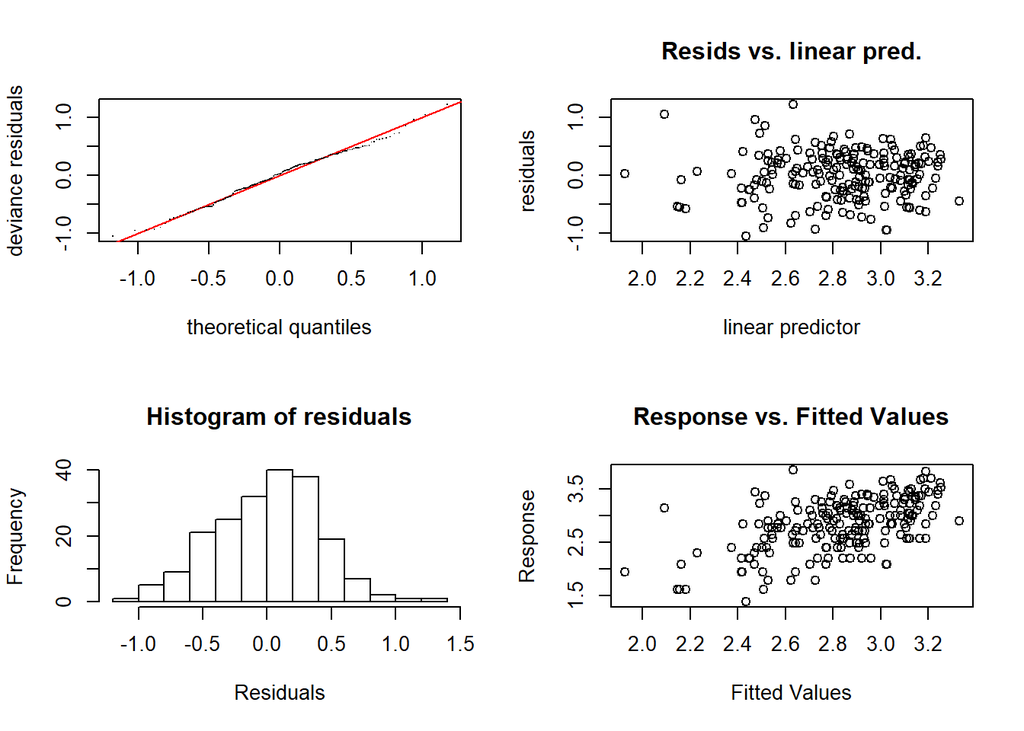

```
##
## Method: GCV   Optimizer: magic
## Smoothing parameter selection converged after 6 iterations.
## The RMS GCV score gradient at convergence was 1.702051e-07 .
## The Hessian was positive definite.
## Model rank =  18 / 18
##
## Basis dimension (k) checking results. Low p-value (k-index<1) may
## indicate that k is too low, especially if edf is close to k'.
##
##                k'  edf k-index p-value
## s(P_mg_100g) 7.00 4.51    1.08    0.90
## s(K_mg_100g) 9.00 7.88    1.15    0.99
```

```r
par(mfrow = c(2,2))
gam.check(spp.gam3)
```

#### GAMM (Generalized Aditive Mixed Models)

To simulate a GAMM model we take the dependent and almost all predictor variables as we used in the previous GAM example. Our intention here is to also include random effects in our modeling, rather than only fixed effects as we did in GAM analysis.

```r
Hogweed <- read.table("Hogweed.csv", header=T, sep=",", dec=".")
head(Hogweed,4)
```

```
##   Plot Study.area  Habitat.type Year Veg.height Veg.cover Species.richness
## 1   s1        VOL ruderal.grass 2002        0.5        70               18
## 2   s2        VOL ruderal.grass 2002        0.7        65               19
## 3   s3        VOL ruderal.grass 2002        0.4        30               16
## 4   s4        VOL ruderal.grass 2002        0.9        90               23
##   Hogweed.height Hogweed.cover Land.use Disturbance Altitude Inclination
## 1            0.9            80     NONE   TREESHRUB  295.653           2
## 2            1.4            65     NONE   TREESHRUB  295.653           2
## 3            1.7            90     NONE   TREESHRUB  295.653           2
## 4            1.0            20     NONE        NONE  292.112           2
##   Exposition N_perc P_mg_100g K_mg_100g
## 1          W   0.19      3.99     22.27
## 2          W   0.19      3.56     12.49
## 3          W   0.19      8.44     39.95
## 4          W   0.12      2.53     12.34
```

```r
library(mgcv) # carry out GAMM model

spp.gamm<- gamm(log(Species.richness) ~ s(Hogweed.cover) + s(P_mg_100g), random =
                          list(Study.area = ~ 1), data=Hogweed, family="gaussian")

summary(spp.gamm)
```

```
##     Length Class Mode
## lme 18     lme   list
## gam 31     gam   list
```

Similar to the summary of the GAM model, we have two types of output: parametric coefficients i.e., the slope of the predictor that indicated a linear relationship and was not smoothed and the non-linear predictors with smoothing and their F and p-values for significance.

```r
anova(spp.gamm$gam)
```

```
##
## Family: gaussian
## Link function: identity
##
## Formula:
## log(Species.richness) ~ s(Hogweed.cover) + s(P_mg_100g)
##
## Approximate significance of smooth terms:
##                    edf Ref.df      F  p-value
## s(Hogweed.cover) 2.528  2.528 11.014 4.22e-06
## s(P_mg_100g)     1.000  1.000  0.133    0.715
```

Below we again conduct a measure for by concurvity between the predictors in the model, to consider non-linear correlations.

```r
concurvity(spp.gamm$gam, full=FALSE)
```

```
## $worst
##                          para s(Hogweed.cover) s(P_mg_100g)
## para             1.000000e+00     5.664068e-17 1.496793e-25
## s(Hogweed.cover) 5.664067e-17     1.000000e+00 1.688794e-01
## s(P_mg_100g)     1.479572e-25     1.688794e-01 1.000000e+00
##
## $observed
##                          para s(Hogweed.cover) s(P_mg_100g)
## para             1.000000e+00     4.617211e-23 4.695046e-33
## s(Hogweed.cover) 5.664067e-17     1.000000e+00 5.838020e-02
## s(P_mg_100g)     1.479572e-25     1.101885e-01 1.000000e+00
##
## $estimate
##                          para s(Hogweed.cover) s(P_mg_100g)
## para             1.000000e+00     9.403869e-20 2.916900e-28
## s(Hogweed.cover) 5.664067e-17     1.000000e+00 4.726491e-02
## s(P_mg_100g)     1.479572e-25     8.170693e-02 1.000000e+00
```

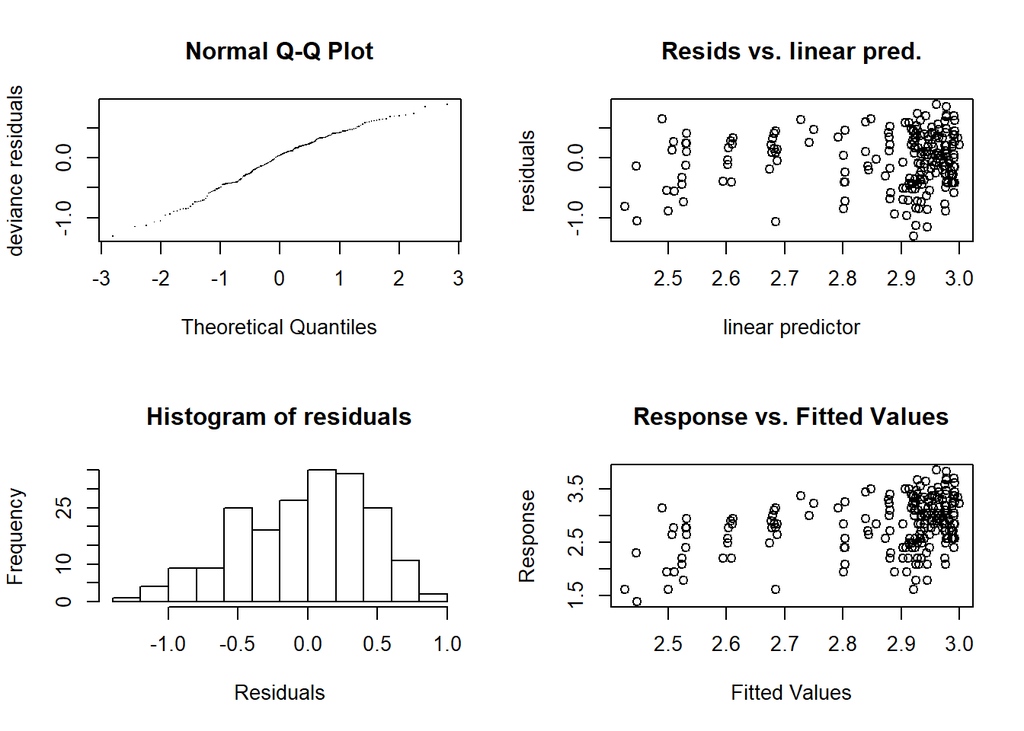

```
##
## 'gamm' based fit - care required with interpretation.
## Checks based on working residuals may be misleading.
## Basis dimension (k) checking results. Low p-value (k-index<1) may
## indicate that k is too low, especially if edf is close to k'.
##
##                    k'  edf k-index p-value
## s(Hogweed.cover) 9.00 2.53    0.78  <2e-16 ***
## s(P_mg_100g)     9.00 1.00    0.90   0.065 .
## ---
## Signif. codes:  0 '***' 0.001 '**' 0.01 '*' 0.05 '.' 0.1 ' ' 1
```

```r
# Residuals
par(mfrow = c(2,2))
gam.check(spp.gamm$gam)
```

Here the graphical residuals looks fine in general. However, the predictor “Hogweed.cover” has significant low p-value for k. In order to remember: “k-index” is the ratio of the neighbor differencing scale estimate to fitted model scale estimate; “edf” is the previously mentioned estimated degrees of freedom and “k” is the maximum possible EDF for the term. These parameters test whether the basis dimension for a smoothing is adequate for the predictor.Therefore, here you can try to improve the model by setting different number of knots (k) and maybe choosing another smooth term for this predictor (e.g. “gp” (Gaussian process), “tp” (Thin plate regression splines) and others. Please, check this out searching for “smooth.terms” documentation of the package mgcv.

### SUPERVISED LEARNING

#### Random Forest

The Random Forest model is a supervised learning technique that generates multiple models from a training dataset on the given data and then simply combines their output rules (predictive variables), thus generating a robust high performance model that corrects overfitting and balances variance inequalities. That is, this model improves the predictive power from decision trees, reducing their variances by calculating their averages. The decision tree is a type of modeling that operates with information gain on each node, classifying data points with greater information increment on each node. When all nodes are depleted for their information gain ratings, the model achieves its optimal performance result. Thus, the Random Forest model is considered, in many cases, to be the most robust decision tree approach.

In its results, the Random Forest provides a percentage explanation of the Y variance from the whole set of predictors considered. It also provides the mean square residual error in the predictions from an approach called “Out of Bag Error Estimation (OBB)”, a robust and efficient method of fitting and error estimation.

```r
Hogweed <- read.table("Hogweed.csv", header=T, sep=",", dec=".")
Hogweed$Plot <- as.integer(Hogweed$Plot) # Transform predictor Plot that is factor
                                        # in integer, since random Forest cannot
                                        # handle more the 53 categories
head(Hogweed,4)
```

```
##   Plot Study.area  Habitat.type Year Veg.height Veg.cover Species.richness
## 1    1        VOL ruderal.grass 2002        0.5        70               18
## 2  110        VOL ruderal.grass 2002        0.7        65               19
## 3  126        VOL ruderal.grass 2002        0.4        30               16
## 4  137        VOL ruderal.grass 2002        0.9        90               23
##   Hogweed.height Hogweed.cover Land.use Disturbance Altitude Inclination
## 1            0.9            80     NONE   TREESHRUB  295.653           2
## 2            1.4            65     NONE   TREESHRUB  295.653           2
## 3            1.7            90     NONE   TREESHRUB  295.653           2
## 4            1.0            20     NONE        NONE  292.112           2
##   Exposition N_perc P_mg_100g K_mg_100g
## 1          W   0.19      3.99     22.27
## 2          W   0.19      3.56     12.49
## 3          W   0.19      8.44     39.95
## 4          W   0.12      2.53     12.34
```

```r
# install.packages("randomForest")

library(randomForest)
```

Below we split our data in train (70% of data) and test (30% of data) sets.

```r
set.seed(100)
train <- sample(nrow(Hogweed), 0.7*nrow(Hogweed), replace = FALSE)
train <- sort(train)
TrainSet <- Hogweed[train,] # split the data in train set
TestSet <- Hogweed[-train,] # split the data in test set
head(TrainSet)# visualize if all variables are present in train set
```

```
##    Plot Study.area  Habitat.type Year Veg.height Veg.cover
## 2   110        VOL ruderal.grass 2002        0.7        65
## 3   126        VOL ruderal.grass 2002        0.4        30
## 4   137        VOL ruderal.grass 2002        0.9        90
## 5   148        VOL ruderal.grass 2002        0.7        75
## 8   181        REN ruderal.grass 2002        0.8        90
## 12   22        REN agr.grassland 2002        0.7        95
##    Species.richness Hogweed.height Hogweed.cover    Land.use Disturbance
## 2                19            1.4            65        NONE   TREESHRUB
## 3                16            1.7            90        NONE   TREESHRUB
## 4                23            1.0            20        NONE        NONE
## 5                27            0.8            20        NONE        NONE
## 8                32            1.1            45 MAINTENANCE        NONE
## 12               27            0.6             5   GRASSLAND        NONE
##    Altitude Inclination Exposition N_perc P_mg_100g K_mg_100g
## 2   295.653           2          W   0.19      3.56     12.49
## 3   295.653           2          W   0.19      8.44     39.95
## 4   292.112           2          W   0.12      2.53     12.34
## 5   292.112           2          W   0.12      2.53     12.34
## 8   371.930           2          S   0.21      0.55      6.97
## 12  377.433           1          S   0.22      7.44     18.27
```

```r
head(TestSet)# visualize if all variables are present in test set
```

```
##    Plot Study.area  Habitat.type Year Veg.height Veg.cover
## 1     1        VOL ruderal.grass 2002        0.5        70
## 6   159        VOL      woodland 2002        0.2         5
## 7   170        REN agr.grassland 2002        0.8        95
## 9   191        REN ruderal.grass 2002        0.8        90
## 10    2        REN agr.grassland 2002        0.7        90
## 11   11        REN    tall.herbs 2002        0.5        20
##    Species.richness Hogweed.height Hogweed.cover    Land.use Disturbance
## 1                18            0.9            80        NONE   TREESHRUB
## 6                16            0.8            10        NONE        NONE
## 7                33            1.0            45   GRASSLAND     SOILDIS
## 9                19            1.1            85 MAINTENANCE        NONE
## 10               28            0.8            10   GRASSLAND        NONE
## 11               16            1.8            90        NONE     SOILDIS
##    Altitude Inclination Exposition N_perc P_mg_100g K_mg_100g
## 1   295.653           2          W   0.19      3.99     22.27
## 6   298.394           2         NW   0.16      2.62     10.77
## 7   394.018           2          S   0.24      5.42     20.46
## 9   371.930           2          S   0.21      0.55      6.97
## 10  374.018           0          0   0.22      5.86     15.13
## 11  379.444           0          0   0.38      0.96     20.34
```

```r
summary(TrainSet)# visualize if all data for train set is correct, i.e.
```

```
##       Plot          Study.area        Habitat.type      Year
##  Min.   :  4.00   NIE    :14   agr.grassland:28    Min.   :2002
##  1st Qu.: 55.75   RUH    :14   ruderal.grass:38    1st Qu.:2002
##  Median :103.00   HEL    :13   tall.herbs   :46    Median :2002
##  Mean   :103.11   ENG    :11   wasteland    :13    Mean   :2002
##  3rd Qu.:150.25   DOM    :10   woodland     :15    3rd Qu.:2003
##  Max.   :200.00   BRE    : 9                       Max.   :2003
##                   (Other):69
##    Veg.height       Veg.cover     Species.richness Hogweed.height
##  Min.   :0.1000   Min.   : 1.00   Min.   : 4.00    Min.   :0.2500
##  1st Qu.:0.3500   1st Qu.:40.00   1st Qu.:13.00    1st Qu.:0.6875
##  Median :0.5000   Median :80.00   Median :18.00    Median :0.9000
##  Mean   :0.5539   Mean   :64.49   Mean   :19.44    Mean   :0.9246
##  3rd Qu.:0.7000   3rd Qu.:90.00   3rd Qu.:25.25    3rd Qu.:1.1000
##  Max.   :1.7000   Max.   :99.00   Max.   :47.00    Max.   :1.9000
##
##  Hogweed.cover          Land.use     Disturbance    Altitude
##  Min.   : 1.00   GRASSLAND  :18   DEPORG   : 6   Min.   :127.6
##  1st Qu.:10.00   MAINTENANCE:26   FLOOD    :13   1st Qu.:208.0
##  Median :20.00   NONE       :96   NONE     :99   Median :322.0
##  Mean   :34.55                    SOILDIS  : 7   Mean   :357.9
##  3rd Qu.:60.00                    TREESHRUB:15   3rd Qu.:439.5
##  Max.   :95.00                                   Max.   :977.0
##
##   Inclination     Exposition     N_perc         P_mg_100g
##  Min.   : 0.0   0      :95   Min.   :0.0400   Min.   : 0.000
##  1st Qu.: 0.0   W      :12   1st Qu.:0.2100   1st Qu.: 0.525
##  Median : 0.0   E      :10   Median :0.2700   Median : 1.405
##  Mean   : 1.4   SW     : 8   Mean   :0.2853   Mean   : 3.128
##  3rd Qu.: 2.0   S      : 5   3rd Qu.:0.3425   3rd Qu.: 3.377
##  Max.   :30.0   N      : 4   Max.   :1.0300   Max.   :31.420
##                 (Other): 6
##    K_mg_100g
##  Min.   : 1.440
##  1st Qu.: 5.728
##  Median : 8.329
##  Mean   :11.639
##  3rd Qu.:13.135
##  Max.   :77.769
##
```

```r
# Min, Median, Mean, Max...
summary(TestSet) # visualize if all data for test set is correct
```

```
##       Plot          Study.area        Habitat.type      Year
##  Min.   :  1.00   GOE    : 6   agr.grassland: 8    Min.   :2002
##  1st Qu.: 46.00   NIE    : 6   ruderal.grass:15    1st Qu.:2002
##  Median :100.00   WAT    : 6   tall.herbs   :31    Median :2002
##  Mean   : 96.16   RUH    : 5   wasteland    : 3    Mean   :2002
##  3rd Qu.:156.00   WEN    : 5   woodland     : 4    3rd Qu.:2003
##  Max.   :201.00   DAH    : 4                       Max.   :2003
##                   (Other):29
##    Veg.height       Veg.cover    Species.richness Hogweed.height
##  Min.   :0.2000   Min.   : 5.0   Min.   : 5.00    Min.   :0.300
##  1st Qu.:0.4000   1st Qu.:40.0   1st Qu.:13.00    1st Qu.:0.800
##  Median :0.5000   Median :70.0   Median :17.00    Median :1.000
##  Mean   :0.5893   Mean   :61.9   Mean   :18.33    Mean   :1.023
##  3rd Qu.:0.7000   3rd Qu.:90.0   3rd Qu.:24.00    3rd Qu.:1.200
##  Max.   :1.4000   Max.   :98.0   Max.   :46.00    Max.   :2.400
##
##  Hogweed.cover          Land.use     Disturbance    Altitude
##  Min.   : 5.00   GRASSLAND  : 6   DEPORG   : 5   Min.   :104.5
##  1st Qu.:15.00   MAINTENANCE: 7   FLOOD    : 8   1st Qu.:206.9
##  Median :40.00   NONE       :48   NONE     :36   Median :316.1
##  Mean   :43.11                    SOILDIS  : 7   Mean   :329.7
##  3rd Qu.:75.00                    TREESHRUB: 5   3rd Qu.:355.0
##  Max.   :90.00                                   Max.   :978.0
##
##   Inclination       Exposition     N_perc         P_mg_100g
##  Min.   : 0.000   0      :28   Min.   :0.0900   Min.   : 0.020
##  1st Qu.: 0.000   S      : 8   1st Qu.:0.2000   1st Qu.: 0.820
##  Median : 1.000   W      : 8   Median :0.2500   Median : 2.280
##  Mean   : 1.918   E      : 5   Mean   :0.2721   Mean   : 3.431
##  3rd Qu.: 2.000   N      : 5   3rd Qu.:0.3400   3rd Qu.: 4.040
##  Max.   :25.000   NW     : 2   Max.   :0.7200   Max.   :26.010
##                   (Other): 5
##    K_mg_100g
##  Min.   : 0.75
##  1st Qu.: 6.32
##  Median : 7.90
##  Mean   :12.39
##  3rd Qu.:14.78
##  Max.   :47.74
##
```

Verify the best number of predictors (mtry) per node (split) in the branches of the decision trees. The function “mtry” shows from which number of predictors per node the prediction errors are lower, based on OBB error (Out of bag) estimation.

```r
# check how many predictors per node reduce error:

tuneRF(Hogweed, Hogweed$Species.richness)
```

```
## mtry = 5  OOB error = 6.304418
## Searching left ...
## mtry = 3     OOB error = 12.58651
## -0.9964583 0.05
## Searching right ...
## mtry = 10    OOB error = 1.960619
## 0.6890087 0.05
## mtry = 17    OOB error = 0.6492911
## 0.6688337 0.05
```

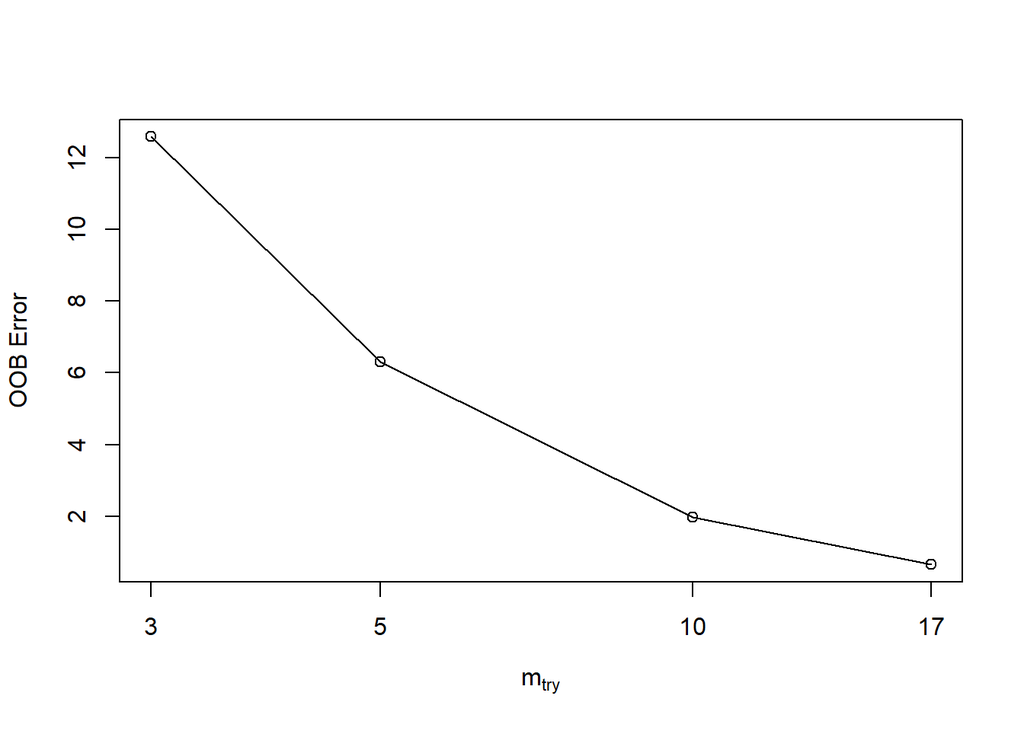

```
##    mtry   OOBError
## 3     3 12.5865073
## 5     5  6.3044180
## 10   10  1.9606194
## 17   17  0.6492911
```

The outcome shows that increasing the number of predictors per node of the trees decreases the error. Thus, we include all predictors (16) per node in the model.

#### Random Forest Model

```r
set.seed(100)
RF1 <- randomForest(Species.richness ~ ., data=Hogweed,
                    subset=train, mtry = 16, importance=TRUE, ntree=500)
```

```r
print(RF1)
```

```
##
## Call:
##  randomForest(formula = Species.richness ~ ., data = Hogweed,      mtry = 16, importance = TRUE, ntree = 500, subset = train)
##                Type of random forest: regression
##                      Number of trees: 500
## No. of variables tried at each split: 16
##
##           Mean of squared residuals: 40.6848
##                     % Var explained: 47.48
```

The model with train subset performed poorly regarding the percentage of variance explained in the prediction of species richness by the selected set of predictors.

Let’s see if the number of decision (500) chosen for the model were enough to reduce the errors:

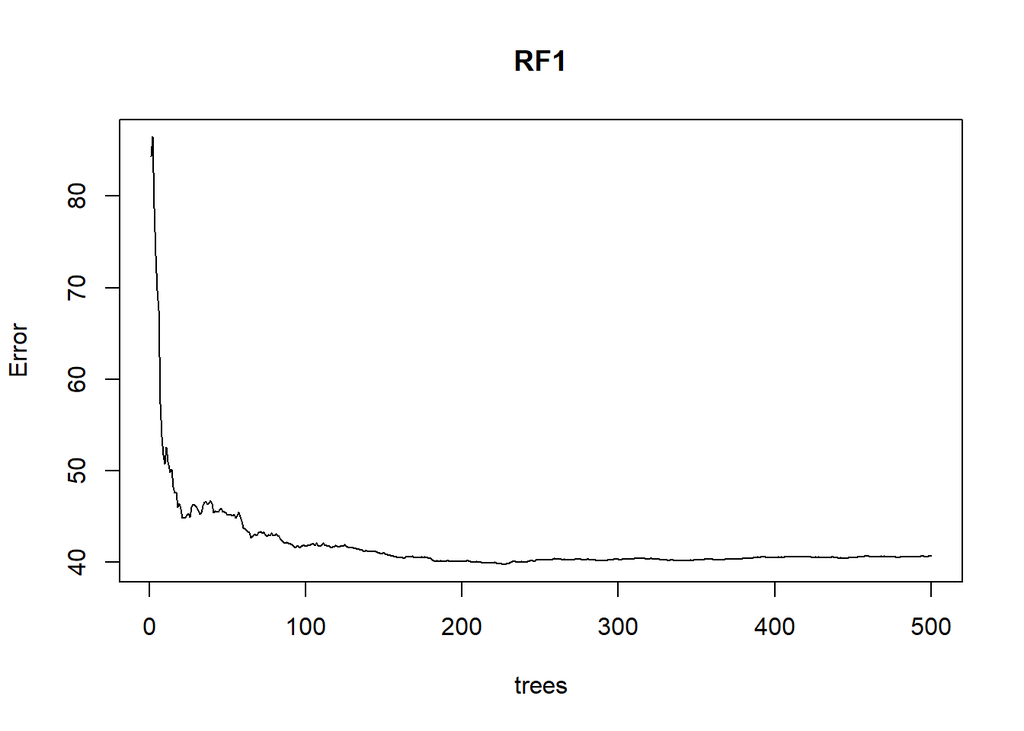

```r
plot(RF1)
```

#### Importance of predictors

Here we check which predictors are the least and most important when predicting the variation of the dependent variable. The variable importance in Random Forest is computed based on Node Purity and Mean squared error. Node purity measures the total decrease of impurities in the nodes (splits) by computing the average of each predictor over the nodes of all trees, being measured, in regression, by the sum of the squares residuals. Of these two approaches for importance, Mean squared error (%IncMSE) is the most robust and informative measure, where the higher number, the more important the variable. Conversely, IncNodePurity is biased and should only be used if the extra computation time of calculating %IncMSE is challenging. Since the %IncMSE is calculated based on OBB estimation, the expectation is that the MSE will increase, especially if the variable has some importance, thus the label “% IncMSE”.

```r
import<- importance(RF1)
import
```

```
##                   %IncMSE IncNodePurity
## Plot            5.5707559     294.35118
## Study.area     37.1460387    5757.91498
## Habitat.type   10.9296666     558.60044
## Year            1.7781753       5.62926
## Veg.height      4.6763764     250.32433
## Veg.cover      12.7326538     652.26748
## Hogweed.height 10.7277820     627.23769
## Hogweed.cover   2.2307121     341.24214
## Land.use       -0.8118798      27.13485
## Disturbance     8.2167514     221.78219
## Altitude        6.3721603     387.67738
## Inclination     1.0159853      66.17019
## Exposition      6.1613376     228.69195
## N_perc          0.4512169     389.86253
## P_mg_100g       3.2757968     362.76719
## K_mg_100g       3.2115987     378.80948
```

The outcome states that the most important predictors based on %IncMSE. Remember that the higher number, the more important the variable.

```r
### save output of importance

write.table(import, "Importance.csv", row.names=T, sep=",", dec=".")
```

Note: Prior to selecting the predictor variables for the Random Forest model, verify whether there is high correlation among them. The presence of highly correlated predictors may bias the computation of importance of each one, for predicting the dependent variable, leading to suboptimal predictor variables being artificially and arbitrarily preferred. For more information about this topic, please read the recommended papers below:

Strobl C, Boulesteix AL, Zeileis A, Hothorn T.Bias in random forest variable importance measures: illustrations, sources and a solution. BMC Bioinformatics, 2007 Jan 25;8:25

Strobl C et al. Conditional variable importance for random forests. BMC Bioinformatics, BMC Bioinformatics. 2008 Jul 11;9:307

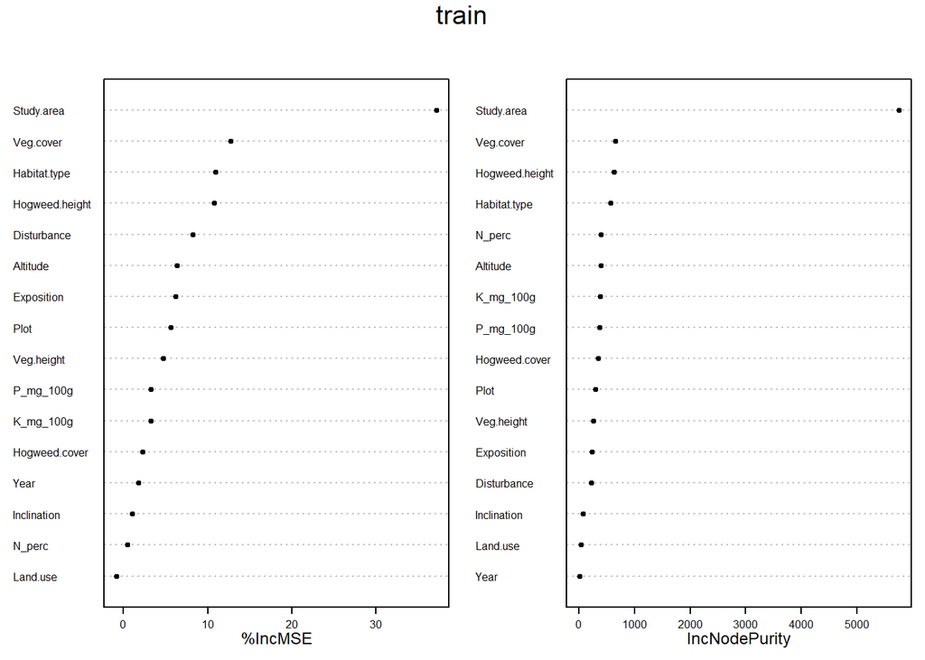

```r
# Shows and save importance graphically

# library(lattice) # save the figure:
# tiff(filename="Fig_IMPORTANCE2019.jpg", width=180, height=80, units="mm", res=300)

varImpPlot(RF1, sort=TRUE, main=deparse(substitute(train)),
           cex.lab=1.5, las=1, bty="n", cex=0.5,pch=19, col='black')
```

```r
# dev.off() ## turn off the graphics device
```

#### Comparison of the level of error

Here we compare the level of error of the model in relation to the number of predictors per node for the train (70%) and test (30%) set.

The OBB (out of bag error estimation) is computed to the train set and compared to the test set (test.err).

Here we simulate whether the inclusion of all predictors per node of the trees delivers a better or worse performance for the random forest prediction of both train and test set. Then, we reduce the number of trees from 500 to 400 to better fit the whole number of predictors per node.

```r
oob.err=double(16) # 16 regards to total number of predictors
test.err=double(16)

for(mtry in 1:16)
{
  rf=randomForest(Species.richness ~ . , data = Hogweed , subset = train,mtry=mtry,ntree=400)
  oob.err[mtry] = rf$mse[400] # Error of all trees adjusted

  pred<-predict(rf,Hogweed[-train,]) # Prediction in test set for each tree
  # Mean Squared Test Error:
  test.err[mtry]= with(Hogweed[-train,], mean( (Species.richness - pred)^2))

  cat(mtry," ") # show the outcome in R console

}
```

```
## 1  2  3  4  5  6  7  8  9  10  11  12  13  14  15  16
```

```r
test.err
```

```
##  [1] 37.56997 37.04643 35.65082 34.96186 35.11245 34.40052 34.58925
##  [8] 35.19916 35.18508 35.20572 34.94613 35.69522 35.74131 35.61271
## [15] 36.48326 36.70819
```

```r
oob.err
```

```
##  [1] 41.77874 39.09036 39.01873 40.45448 40.88128 38.47648 40.33007
##  [8] 40.92160 39.89282 39.65230 40.56144 40.65620 40.93758 41.32343
## [15] 41.05698 40.28447
```

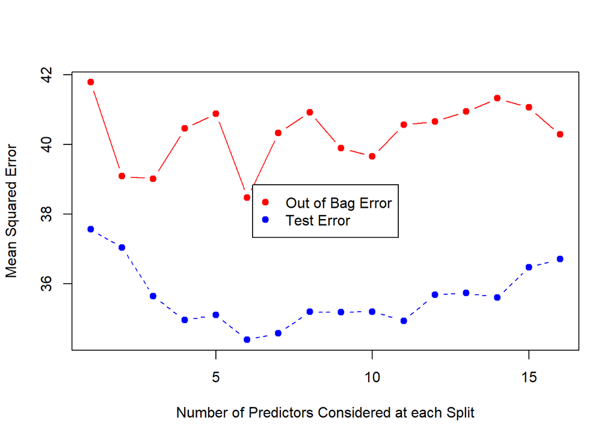

```r
matplot(1:mtry , cbind(oob.err,test.err), pch=19 , col=c("red","blue"),type="b",
        ylab="Mean Squared Error",xlab="Number of Predictors Considered at each Split")
legend("center",legend=c("Out of Bag Error","Test Error"),pch=19, col=c("red","blue"))
```

The graph shows that the mean squared error increases slightly in both Out of bag error and test error as the number of predictors increases at each split (node).

In addition, we can check the performance using cross-validation prediction of models with the number of predictors reducing sequentially. In such reduction, the predictors are ranked by variable importance via a nested cross-validation procedure.

```r
rfcv(Hogweed, Hogweed$Species.richness, cv.fold=5)
```

```
## $n.var
## [1] 17  8  4  2  1
##
## $error.cv
##        17         8         4         2         1
## 8.1906159 7.5375960 2.3589484 2.8383323 0.2002621
##
## $predicted
## $predicted$`17`
##   [1] 17.672433 18.030300 15.337233 22.282800 24.021633 16.897033 28.913267
##   [8] 30.135833 21.520233 26.856300 16.746733 27.260633 15.721633 13.453567
##  [15] 16.507900 19.716600 19.747133 15.485233 23.652200 16.815933 24.503100
##  [22] 22.552900 17.388367 14.350433 20.736033 19.691367 17.359300 22.121633
##  [29] 23.384767 16.301267 18.328810 16.987533 21.580133 28.771967 29.188067
##  [36] 26.065800 26.761333 26.772533 17.291400 14.992867 17.186533 17.125033
```

[output cut: 147 more lines]

The section “$error.cv” in the output show us that reducing number of predictors decreases the rates of error in the performance of the model. This outcome make sense and is congruent with large amount of predictors with low importance for the model prediction observed above.

#### Prediction performance

In order to verify the percentage of explanation for the Random Forest model we can adjust a linear model to get a value for R-squared. We do this for the test set created above. If 30% of data from the test produces a high performance, your prediction is good.

```r
predTest <- predict(RF1, TestSet)
r2_test <- lm(predTest ~ TestSet$Species.richness)
summary(r2_test)
```

```
##
## Call:
## lm(formula = predTest ~ TestSet$Species.richness)
##
## Residuals:
##     Min      1Q  Median      3Q     Max
## -6.3940 -3.0597 -0.1885  2.3862 10.6701
##
## Coefficients:
##                          Estimate Std. Error t value Pr(>|t|)
## (Intercept)              11.04786    1.25847   8.779 2.67e-12 ***
## TestSet$Species.richness  0.44538    0.06282   7.090 1.91e-09 ***
## ---
## Signif. codes:  0 '***' 0.001 '**' 0.01 '*' 0.05 '.' 0.1 ' ' 1
##
## Residual standard error: 3.968 on 59 degrees of freedom
## Multiple R-squared:   0.46,  Adjusted R-squared:  0.4509
## F-statistic: 50.26 on 1 and 59 DF,  p-value: 1.907e-09
```

The adjusted R-squared shows that the prediction performance of the model is not good, since it predicts less than 50 % of the dependent variable.

Nevertheless, you do not need necessarily to use a linear model to check on prediction performance. You could also calculate the correlation coefficient and, then, square it:

```r
cor(predTest, TestSet$Species.richness) ^ 2
```

```
## [1] 0.4600236
```

#### RMSE

We can adjust a RMSE (Root mean squared error) for the model. The RMSE is particularly useful when it is compared with other models to see if it performs better or worse depending if it has a higher or lower error of prediction.

```r
rfvalpred = predict(RF1,newdata=TestSet)
rmse = sqrt(mean((TestSet$Species.richness-rfvalpred)^2))
rmse
```

```
## [1] 6.010385
```

### Model Selection (Akaike)

For both Akaike and GLM / GLMM the predictor variables must be tested for the degree of correlation, because if these variables are highly correlated, it implies collinearity, and the real contributions of each predictor to the dependent variable may be confounded. One conventional way to test correlation, and collinearity, is the Pearson’s correlation (described in this script). Pearson correlation coefficients can be between -1 and 1, and the accepted limit for collinearity is |0.60|. Correlations above 0.60 indicate too much collinearity between predictors. On the other hand, many authors accept correlations up to 0.70 and use variables with this degree of correlation in the model.

Akaike’s function: select the best regression model according to the relationship between the dependent and predictor variables. The best model is normally assumed to be the one with the lowest AICc value. However, the quantity of models considered to be good does not necessarily follow a specific rule, since it depends on your purpose and research approach. It also can depend on the statistical line you follow. Some researchers suggest that a difference between AIC values smaller than 2 (i.e. delta AIC =< 2) indicates that the models are almost equally good. Others use a threshold level of delta AIC =< 4.

#### GLM’s Akaike selection

```r
## Akaike: basic syntax

## install and load "MuMIn" package

# Usage

Hogweed <- read.table("Hogweed.csv", header=T, sep=",", dec=".")
head(Hogweed,4)
```

```
##   Plot Study.area  Habitat.type Year Veg.height Veg.cover Species.richness
## 1   s1        VOL ruderal.grass 2002        0.5        70               18
## 2   s2        VOL ruderal.grass 2002        0.7        65               19
## 3   s3        VOL ruderal.grass 2002        0.4        30               16
## 4   s4        VOL ruderal.grass 2002        0.9        90               23
##   Hogweed.height Hogweed.cover Land.use Disturbance Altitude Inclination
## 1            0.9            80     NONE   TREESHRUB  295.653           2
## 2            1.4            65     NONE   TREESHRUB  295.653           2
## 3            1.7            90     NONE   TREESHRUB  295.653           2
## 4            1.0            20     NONE        NONE  292.112           2
##   Exposition N_perc P_mg_100g K_mg_100g
## 1          W   0.19      3.99     22.27
## 2          W   0.19      3.56     12.49
## 3          W   0.19      8.44     39.95
## 4          W   0.12      2.53     12.34
```

```r
# install.packages("MuMIn")
library(MuMIn)
options(na.action = "na.fail")
div <- glm(Veg.height ~ P_mg_100g + K_mg_100g + Land.use, family=gaussian,
           data=Hogweed)
tested.div1 <- dredge(div)
tested.div1
```

```
## Global model call: glm(formula = Veg.height ~ P_mg_100g + K_mg_100g + Land.use,
##     family = gaussian, data = Hogweed)
## ---
## Model selection table
##    (Int)   K_mg_100 Lnd.use P_mg_100 df  logLik AICc delta weight
## 7 0.3256                  + 0.006875  5 -23.238 56.8  0.00  0.414
## 3 0.3396                  +           4 -24.592 57.4  0.60  0.306
## 8 0.3330 -0.0011540       + 0.008192  6 -23.093 58.6  1.83  0.165
## 4 0.3336  0.0006829       +           5 -24.525 59.4  2.57  0.114
## 5 0.5353                    0.009135  3 -32.343 70.8 14.02  0.000
## 6 0.5399 -0.0005695         0.009789  4 -32.310 72.8 16.04  0.000
## 1 0.5647                              2 -34.565 73.2 16.41  0.000
## 2 0.5450  0.0016610                   3 -34.197 74.5 17.73  0.000
## Models ranked by AICc(x)
```

#### LME’s Akaike selection

Firstly you must carry out the pre-tests with LM in the model to be executed as LME model. If normality and linearity are accepted, then, you check for spatial autocorrelation by Moran’s I. If there is significant autocorrelation you must model include a spatial correlation structure (e.g. corExp) within the global LME that will be submited to selection by Akaike such as the example below.

Example of LM model to check for linearity and autocorrelation for the global LME model to execute Akaike’s selection:

Firstly you must conduct pre-tests with LMs in the model to be executed as LME model. If normality and linearity are acceptable, you must then check for spatial autocorrelation by Moran’s I. If there is significant autocorrelation your model must include a spatial correlation structure (e.g. corExp) within the global LME, which will be submitted to selection by Akaike criteria, as described in the example below.

```r
BIOVEG <- read.table("BIOVEG3.csv", header=T, sep=",", dec=".")
head(BIOVEG,4)
```

```
##           type Plot  Site                Species Richness Diameter
## 1 Semidecidual p001 AREA1 Alchornea_triplinervia        8    27.12
## 2 Semidecidual p002 AREA1     Amaioua_intermedia       10    39.15
## 3 Semidecidual p003 AREA1          Aniba_firmula       10    33.93
## 4 Semidecidual p004 AREA1          Annona_cacans       10    40.43
##   Mean_diameter Basal.area Abundance Precipitation_mean Temperature_mean
## 1         6.357      0.058         7               1250             24.4
## 2         6.524      0.120        12               1250             24.4
## 3         6.632      0.090        10               1250             24.4
## 4         6.626      0.128        19               1250             24.4
##   Mortality Recruitment local.x local.y  utm.x   utm.y local.utm.x
## 1      6.94       14.34       0       0 747923 7807727      747923
## 2      2.74        6.94     -10       0 747923 7807727      747913
## 3      1.71        2.35     -20       0 747923 7807727      747903
## 4      1.60        2.47     -30       0 747923 7807727      747893
##   local.utm.y
## 1     7807727
## 2     7807727
## 3     7807727
## 4     7807727
```

```r
Mean.Diameter.pre <- lm(Mean_diameter ~ Mortality + Recruitment + Richness + Site,
                                                                  data=BIOVEG)
```

```r
## LME's Akaike selection

library(nlme) # LME models
library(MuMIn) # Dredge function to execute the selection

options(na.action = "na.fail")
div <- lme(Mean_diameter ~ Mortality + Recruitment + Richness, data=BIOVEG, method="ML", random= ~1|Site, corr=corExp(form=~local.utm.x+local.utm.y|Site),
                                  weights=varIdent(form=~1|Site), na.action=na.fail)


tested.div1 <- dredge(div)
tested.div1
```

```
## Global model call: lme.formula(fixed = Mean_diameter ~ Mortality + Recruitment +
##     Richness, data = BIOVEG, random = ~1 | Site, correlation = corExp(form = ~local.utm.x +
##     local.utm.y | Site), weights = varIdent(form = ~1 | Site),
##     method = "ML", na.action = na.fail)
## ---
## Model selection table
##   (Intrc)    Mrtlt     Rcrtm      Rchns df  logLik  AICc delta weight
## 1   10.67                                6 -40.724  94.0  0.00  0.403
## 2   10.67 0.001550                       7 -40.609  96.0  1.97  0.150
## 3   10.67          -0.002797             7 -40.678  96.1  2.11  0.140
## 5   10.68                    -0.0007914  7 -40.686  96.2  2.13  0.139
## 4   10.67 0.001605 -0.003023             8 -40.555  98.1  4.10  0.052
## 6   10.67 0.001428           -0.0005343  8 -40.593  98.2  4.17  0.050
## 7   10.69          -0.002982 -0.0008561  8 -40.634  98.3  4.25  0.048
## 8   10.68 0.001472 -0.003134 -0.0005951  9 -40.535 100.4  6.32  0.017
## Models ranked by AICc(x)
## Random terms (all models):
## '1 | Site'
```

#### QAIC - Quasipoisson

```r
Hogweed <- read.table("Hogweed.csv", header=T, sep=",", dec=".")
head(Hogweed,4)
```

```
##   Plot Study.area  Habitat.type Year Veg.height Veg.cover Species.richness
## 1   s1        VOL ruderal.grass 2002        0.5        70               18
## 2   s2        VOL ruderal.grass 2002        0.7        65               19
## 3   s3        VOL ruderal.grass 2002        0.4        30               16
## 4   s4        VOL ruderal.grass 2002        0.9        90               23
##   Hogweed.height Hogweed.cover Land.use Disturbance Altitude Inclination
## 1            0.9            80     NONE   TREESHRUB  295.653           2
## 2            1.4            65     NONE   TREESHRUB  295.653           2
## 3            1.7            90     NONE   TREESHRUB  295.653           2
## 4            1.0            20     NONE        NONE  292.112           2
##   Exposition N_perc P_mg_100g K_mg_100g
## 1          W   0.19      3.99     22.27
## 2          W   0.19      3.56     12.49
## 3          W   0.19      8.44     39.95
## 4          W   0.12      2.53     12.34
```

```r
# install.packages("MuMIn")
library(MuMIn)
options(na.action = "na.fail")
```

Fist, we execute the function for “x.quasipossion” constructor, which allows for quasipoisson family objects, for ML estimation.

```r
x.quasipoisson <- function(...) {
  res <- quasipoisson(...)
  res$aic <- poisson(...)$aic
  res
}
```

```r
riqueza.glm2<- glm(Species.richness ~ P_mg_100g + Land.use + K_mg_100g
                + Hogweed.height, data=Hogweed, family="x.quasipoisson")
```

To compute the variance inflation factor based on residuals of Pearson, where it is necessary to use the “dredge” function to compute the QAIC values and its parameters. There is a discussion among statisticians regarding whether residuals of Pearson are suitable for models (e.g. Poisson and Binomial) based on Chisq, but there are various examples where it provides a robust and reliable fit.

```r
chat<-sum(residuals(riqueza.glm2,"pearson")^2)/riqueza.glm2$df.residual
chat
```

```
## [1] 3.231642
```

```r
riqueza.QAIC <- dredge(riqueza.glm2, rank = "QAIC", chat = chat)
```

```
## Fixed term is "(Intercept)"
```

```r
riqueza.QAIC
```

```
## Global model call: glm(formula = Species.richness ~ P_mg_100g + Land.use + K_mg_100g +
##     Hogweed.height, family = "x.quasipoisson", data = Hogweed)
## ---
## Model selection table
##    (Int) Hgw.hgh  K_mg_100 Lnd.use P_mg_100 df   logLik  QAIC delta weight
## 10 3.412 -0.4344                   -0.02074  3 -788.820 496.2  0.00  0.478
## 12 3.432 -0.4319 -0.002688         -0.01770  4 -787.878 497.6  1.42  0.235
## 14 3.433 -0.3805                 + -0.01978  5 -786.527 498.8  2.58  0.131
## 16 3.449 -0.3805 -0.002554       + -0.01689  6 -785.687 500.2  4.06  0.063
## 4  3.433 -0.4422 -0.006557                   3 -795.857 500.5  4.35  0.054
## 8  3.450 -0.3837 -0.006229       +           5 -792.800 502.6  6.46  0.019
## 2  3.368 -0.4539                             2 -803.606 503.3  7.15  0.013
## 6  3.396 -0.3839                 +           4 -799.668 504.9  8.71  0.006
## 13 3.263                         + -0.02047  4 -814.401 514.0 17.83  0.000
## 15 3.280         -0.002651       + -0.01747  5 -813.488 515.5 19.27  0.000
## 7  3.277         -0.006323       +           4 -820.933 518.1 21.87  0.000
## 5  3.222                         +           3 -827.998 520.4 24.25  0.000
## 9  3.022                           -0.02408  2 -839.309 525.4 29.25  0.000
## 11 3.050         -0.003526         -0.02014  3 -837.648 526.4 30.22  0.000
## 3  3.038         -0.007717                   2 -847.930 530.8 34.58  0.000
## 1  2.950                                     1 -858.742 535.5 39.27  0.000
## Models ranked by QAIC(x, chat = 3.23164202774229)
```

We can compare the QAIC selection by using Pearson’s residuals to fit variance inflation factor, by dividing the deviance by residual degrees of freedom.

```r
chat2=(deviance(riqueza.glm2) / df.residual(riqueza.glm2))

riqueza2.QAIC <- dredge(riqueza.glm2, rank = "QAIC", chat = chat2)
```

```
## Fixed term is "(Intercept)"
```

```r
riqueza2.QAIC
```

```
## Global model call: glm(formula = Species.richness ~ P_mg_100g + Land.use + K_mg_100g +
##     Hogweed.height, family = "x.quasipoisson", data = Hogweed)
## ---
## Model selection table
##    (Int) Hgw.hgh  K_mg_100 Lnd.use P_mg_100 df   logLik  QAIC delta weight
## 10 3.412 -0.4344                   -0.02074  3 -788.820 497.1  0.00  0.478
## 12 3.432 -0.4319 -0.002688         -0.01770  4 -787.878 498.5  1.42  0.235
## 14 3.433 -0.3805                 + -0.01978  5 -786.527 499.6  2.58  0.132
## 16 3.449 -0.3805 -0.002554       + -0.01689  6 -785.687 501.1  4.06  0.063
## 4  3.433 -0.4422 -0.006557                   3 -795.857 501.4  4.36  0.054
## 8  3.450 -0.3837 -0.006229       +           5 -792.800 503.5  6.47  0.019
## 2  3.368 -0.4539                             2 -803.606 504.2  7.17  0.013
## 6  3.396 -0.3839                 +           4 -799.668 505.8  8.73  0.006
## 13 3.263                         + -0.02047  4 -814.401 514.9 17.86  0.000
## 15 3.280         -0.002651       + -0.01747  5 -813.488 516.3 19.29  0.000
## 7  3.277         -0.006323       +           4 -820.933 519.0 21.91  0.000
## 5  3.222                         +           3 -827.998 521.3 24.29  0.000
## 9  3.022                           -0.02408  2 -839.309 526.4 29.30  0.000
## 11 3.050         -0.003526         -0.02014  3 -837.648 527.3 30.27  0.000
## 3  3.038         -0.007717                   2 -847.930 531.7 34.65  0.000
## 1  2.950                                     1 -858.742 536.4 39.35  0.000
## Models ranked by QAIC(x, chat = 3.2258850123267)
```

We see that the outcomes of QAIC selection using the two approaches above, to compute ‘chat’ as the variance inflation factors, results in virtually the same outcomes.

#### QAIC - Quasibinomial

```r
# install.packages("MuMIn")
library(MuMIn)


Hogweed <- read.table("Hogweed.csv", header=T, sep=",", dec=".")
head(Hogweed,4)
```

```
##   Plot Study.area  Habitat.type Year Veg.height Veg.cover Species.richness
## 1   s1        VOL ruderal.grass 2002        0.5        70               18
## 2   s2        VOL ruderal.grass 2002        0.7        65               19
## 3   s3        VOL ruderal.grass 2002        0.4        30               16
## 4   s4        VOL ruderal.grass 2002        0.9        90               23
##   Hogweed.height Hogweed.cover Land.use Disturbance Altitude Inclination
## 1            0.9            80     NONE   TREESHRUB  295.653           2
## 2            1.4            65     NONE   TREESHRUB  295.653           2
## 3            1.7            90     NONE   TREESHRUB  295.653           2
## 4            1.0            20     NONE        NONE  292.112           2
##   Exposition N_perc P_mg_100g K_mg_100g
## 1          W   0.19      3.99     22.27
## 2          W   0.19      3.56     12.49
## 3          W   0.19      8.44     39.95
## 4          W   0.12      2.53     12.34
```

First, let’s execute a ‘hacked’ constructor for quasibinomial family object for ML estimation

```r
x.quasibinomial  <- function(...) {
  res <- quasibinomial(...)
  res$aic <- binomial(...)$aic
  res
}
```

```r
coverHog.glm1 <- glm(Hogweed.cover/100 ~ Veg.height + N_perc +
                       Habitat.type + Land.use + P_mg_100g,
                     data=Hogweed,family="x.quasibinomial")

chat3=(deviance(coverHog.glm1) / df.residual(coverHog.glm1))

options(na.action = "na.fail")
AICselectCover <- dredge(coverHog.glm1)
```

```
## Fixed term is "(Intercept)"
```

```r
AICselectCover
```

```
## Global model call: glm(formula = Hogweed.cover/100 ~ Veg.height + N_perc + Habitat.type +
##     Land.use + P_mg_100g, family = "x.quasibinomial", data = Hogweed)
## ---
## Model selection table
##      (Int) Hbt.typ Lnd.use    N_prc   P_mg_100 Veg.hgh df   logLik  AICc
## 18 -1.0670       +                             -1.4490  6 -103.960 220.4
## 22 -0.9835       +         -0.26910            -1.4480  7 -103.885 222.3
## 26 -1.0640       +                  -0.0021020 -1.4450  7 -103.923 222.4
## 30 -0.9841       +         -0.26550 -0.0003552 -1.4470  8 -103.880 224.5
## 20 -1.2730       +       +                     -1.5110  8 -104.183 225.1
## 28 -1.2680       +       +          -0.0035190 -1.5050  9 -104.119 227.2
## 24 -1.2030       +       + -0.22390            -1.5090  9 -104.125 227.2
## 32 -1.2070       +       + -0.20140 -0.0021360 -1.5050 10 -104.093 229.3
## 2  -1.6180       +                                      5 -111.991 234.3
## 10 -1.5930       +                  -0.0112400          6 -111.663 235.8
```

[output cut: 56 more lines]

### MODEL AVERAGING

With the function “model.avg” of the package MuMIn we can compute model averaging based on an information criterion (e.g. AIC (Akaike) or BIC (Baysean)).

```r
BIOVEG <- read.table("BIOVEG3.csv", header=TRUE, sep=",", dec=".")
head(BIOVEG, 4)
```

```
##           type Plot  Site                Species Richness Diameter
## 1 Semidecidual p001 AREA1 Alchornea_triplinervia        8    27.12
## 2 Semidecidual p002 AREA1     Amaioua_intermedia       10    39.15
## 3 Semidecidual p003 AREA1          Aniba_firmula       10    33.93
## 4 Semidecidual p004 AREA1          Annona_cacans       10    40.43
##   Mean_diameter Basal.area Abundance Precipitation_mean Temperature_mean
## 1         6.357      0.058         7               1250             24.4
## 2         6.524      0.120        12               1250             24.4
## 3         6.632      0.090        10               1250             24.4
## 4         6.626      0.128        19               1250             24.4
##   Mortality Recruitment local.x local.y  utm.x   utm.y local.utm.x
## 1      6.94       14.34       0       0 747923 7807727      747923
## 2      2.74        6.94     -10       0 747923 7807727      747913
## 3      1.71        2.35     -20       0 747923 7807727      747903
## 4      1.60        2.47     -30       0 747923 7807727      747893
##   local.utm.y
## 1     7807727
## 2     7807727
## 3     7807727
## 4     7807727
```

```r
library(MuMIn)
options(na.action = "na.fail")
riqueza <- glm(Richness ~ Mortality + Recruitment + Diameter
               + Temperature_mean, family=gaussian, data=BIOVEG)
riqueza.AICc <- dredge(riqueza)
```

```
## Fixed term is "(Intercept)"
```

```r
riqueza.AICc
```

```
## Global model call: glm(formula = Richness ~ Mortality + Recruitment + Diameter +
##     Temperature_mean, family = gaussian, data = BIOVEG)
## ---
## Model selection table
##     (Int)     Dmt     Mrt     Rcr Tmp_men df   logLik  AICc delta weight
## 5  15.920                 -0.3395          3 -483.219 972.6  0.00  0.140
## 1  15.060                                  2 -484.472 973.0  0.42  0.113
## 6  14.730 0.04540         -0.3990          4 -482.416 973.1  0.50  0.108
## 13  5.449                 -0.4582 0.47360  4 -482.436 973.1  0.55  0.106
## 7  16.350         -0.1435 -0.3391          4 -482.774 973.8  1.22  0.076
## 14  5.844 0.03940         -0.4936 0.40910  5 -481.840 974.1  1.49  0.066
## 3  15.500         -0.1440                  3 -484.031 974.2  1.62  0.062
## 2  14.140 0.03131                          3 -484.079 974.3  1.72  0.059
## 8  15.180 0.04361 -0.1330 -0.3963          5 -482.031 974.5  1.88  0.055
## 15  6.374         -0.1302 -0.4518 0.44970  5 -482.068 974.6  1.95  0.053
## 9  11.170                         0.17120  3 -484.352 974.9  2.27  0.045
## 16  6.704 0.03805 -0.1229 -0.4864 0.38880  6 -481.511 975.6  3.01  0.031
## 4  14.610 0.02957 -0.1369                  4 -483.680 975.6  3.03  0.031
## 11 12.080         -0.1396         0.15010  4 -483.939 976.2  3.55  0.024
## 10 11.780 0.02887                 0.10680  4 -484.035 976.3  3.74  0.021
## 12 12.630 0.02755 -0.1348         0.08937  5 -483.649 977.7  5.11  0.011
## Models ranked by AICc(x)
```

#### Average of the best modes under delta < 4

```r
summary(model.avg(riqueza.AICc, subset = delta < 4))
```

```
##
## Call:
## model.avg(object = riqueza.AICc, subset = delta < 4)
##
## Component model call:
## glm(formula = Richness ~ <15 unique rhs>, family = gaussian, data
##      = BIOVEG)
##
## Component models:
##        df  logLik   AICc delta weight
## 3       3 -483.22 972.60  0.00   0.14
## (Null)  2 -484.47 973.03  0.42   0.11
## 13      4 -482.42 973.11  0.50   0.11
## 34      4 -482.44 973.15  0.55   0.11
## 23      4 -482.77 973.82  1.22   0.08
## 134     5 -481.84 974.10  1.49   0.07
## 2       3 -484.03 974.23  1.62   0.06
## 1       3 -484.08 974.32  1.72   0.06
## 123     5 -482.03 974.48  1.88   0.06
## 234     5 -482.07 974.55  1.95   0.05
## 4       3 -484.35 974.87  2.27   0.05
## 1234    6 -481.51 975.61  3.01   0.03
## 12      4 -483.68 975.64  3.03   0.03
## 24      4 -483.94 976.15  3.55   0.02
## 14      4 -484.03 976.35  3.74   0.02
##
## Term codes:
##         Diameter        Mortality      Recruitment Temperature_mean
##                1                2                3                4
##
## Model-averaged coefficients:
## (full average)
##                  Estimate Std. Error Adjusted SE z value Pr(>|z|)
## (Intercept)      12.51626    6.47186     6.50420   1.924   0.0543 .
## Recruitment      -0.26106    0.26949     0.27049   0.965   0.3345
## Diameter          0.01462    0.02932     0.02946   0.496   0.6196
## Temperature_mean  0.12805    0.29325     0.29466   0.435   0.6639
## Mortality        -0.04573    0.10993     0.11053   0.414   0.6791
##
## (conditional average)
##                  Estimate Std. Error Adjusted SE z value Pr(>|z|)
## (Intercept)      12.51626    6.47186     6.50420   1.924   0.0543 .
## Recruitment      -0.40696    0.23202     0.23383   1.740   0.0818 .
## Diameter          0.03895    0.03664     0.03693   1.055   0.2916
## Temperature_mean  0.36591    0.39838     0.40134   0.912   0.3619
## Mortality        -0.13691    0.15394     0.15522   0.882   0.3777
## ---
## Signif. codes:  0 '***' 0.001 '**' 0.01 '*' 0.05 '.' 0.1 ' ' 1
```

### POST-HOC TEST TO REGRESSION MODELS

A common necessity when using GLM, LM or GLMM using categorical (factor variable) predictors, is to conduct multiple comparison of means among the pairs of categories. Such comparison using regression models is still being developed and improved. For instance, there are currently no 100% robust, standard unbiased post-hoc tests which can be applied in Mixed Models (e.g. GLMM, LME). Below we provide examples of two of the most commonly used post-hoc methods applied in Ecology but we highly advise you to read about their application and carefully consider whether their use is appropriate for your analysis.

If after you run your model, you find a significant difference of the means among categories (as shown by fitting ANOVA to count data in this GLM model example with species richness as target variable), then you need a post-hoc (posteriori) test to show you between which categories the difference occurred. Post-hoc tests on Linear Models become even more important the more predictor variables you use. If you want to run an a posteriori comparison of the model, knowing that there are significant differences among categories as there are in this example, this comparison will consider the weight of other predictor variables (e.g. k, ca, light).

#### TUKEY’S POST HOC TEST (Tukey’s HSD (honest significant difference) test)

```r
BIOVEG <- read.table("BIOVEG3.csv", header=T, sep=",", dec=".")
head(BIOVEG,4)
```

```
##           type Plot  Site                Species Richness Diameter
## 1 Semidecidual p001 AREA1 Alchornea_triplinervia        8    27.12
## 2 Semidecidual p002 AREA1     Amaioua_intermedia       10    39.15
## 3 Semidecidual p003 AREA1          Aniba_firmula       10    33.93
## 4 Semidecidual p004 AREA1          Annona_cacans       10    40.43
##   Mean_diameter Basal.area Abundance Precipitation_mean Temperature_mean
## 1         6.357      0.058         7               1250             24.4
## 2         6.524      0.120        12               1250             24.4
## 3         6.632      0.090        10               1250             24.4
## 4         6.626      0.128        19               1250             24.4
##   Mortality Recruitment local.x local.y  utm.x   utm.y local.utm.x
## 1      6.94       14.34       0       0 747923 7807727      747923
## 2      2.74        6.94     -10       0 747923 7807727      747913
## 3      1.71        2.35     -20       0 747923 7807727      747903
## 4      1.60        2.47     -30       0 747923 7807727      747893
##   local.utm.y
## 1     7807727
## 2     7807727
## 3     7807727
## 4     7807727
```

```r
# Usage

# install.packages("multcomp")
library(multcomp)


richtype <- glm(Richness ~ type, data=BIOVEG, family=poisson)
summary(richtype)
```

```
##
## Call:
## glm(formula = Richness ~ type, family = poisson, data = BIOVEG)
##
## Deviance Residuals:
##     Min       1Q   Median       3Q      Max
## -2.8720  -1.2326  -0.1111   0.8646   5.5989
##
## Coefficients:
##                  Estimate Std. Error z value Pr(>|z|)
## (Intercept)       2.61593    0.03824  68.416  < 2e-16 ***
## typeOmbrofila     0.22197    0.05131   4.326 1.52e-05 ***
## typeSemidecidual  0.05268    0.05338   0.987    0.324
## ---
## Signif. codes:  0 '***' 0.001 '**' 0.01 '*' 0.05 '.' 0.1 ' ' 1
##
## (Dispersion parameter for poisson family taken to be 1)
##
##     Null deviance: 350.25  on 149  degrees of freedom
## Residual deviance: 329.36  on 147  degrees of freedom
## AIC: 1007.9
##
## Number of Fisher Scoring iterations: 4
```

```r
summary(glht(richtype, linfct=mcp(type = "Tukey")))
```

```
##
##   Simultaneous Tests for General Linear Hypotheses
##
## Multiple Comparisons of Means: Tukey Contrasts
##
##
## Fit: glm(formula = Richness ~ type, family = poisson, data = BIOVEG)
##
## Linear Hypotheses:
##                               Estimate Std. Error z value Pr(>|z|)
## Ombrofila - Aluvial == 0       0.22197    0.05131   4.326  < 0.001 ***
## Semidecidual - Aluvial == 0    0.05268    0.05338   0.987  0.58493
## Semidecidual - Ombrofila == 0 -0.16929    0.05058  -3.347  0.00247 **
## ---
## Signif. codes:  0 '***' 0.001 '**' 0.01 '*' 0.05 '.' 0.1 ' ' 1
## (Adjusted p values reported -- single-step method)
```

```r
cldm0 <- cld(glht(richtype, linfct=mcp(type = "Tukey")))
cldm0 # here show between each pairs of type there is the significant difference
```

```
##      Aluvial    Ombrofila Semidecidual
##          "a"          "b"          "a"
```

#### LMERTEST

This test is used for mixed models (e.g. GLMM, LME) which have Pseudoreplication (when your data is distributed in subplots within each site. E.g. 3 sites with 50 10 m x 10 m plots) and you need to consider this effect (normally called random effect, but be careful when reading about this subject since there remains some disagreement between statisticians). For instance, if you need to not only consider data values per site or fragment, but also data values per subplot within each site. Suppose you need to know the phylogenetic diversity per subplot within each site, you need to recognize that the subplots are not real replicates and so you need to use a mixed model.

Atention: The “lmer test” from the package of the same name is one of the most commonly used post-hoc tests in this case, but there remain disagreements among statisticians about its robustness when homogeneity of variance and normality are violated. Read about this method and carefully consider whether it is appropriate for your analysis. The “lmerTest” package calculate p-values of differences of means among categories.

```r
# install.packages("lmerTest")
library(lmerTest)

BIOVEG <- read.table("BIOVEG3.csv", header=T, sep=",", dec=".")
head(BIOVEG,4)
```

```
##           type Plot  Site                Species Richness Diameter
## 1 Semidecidual p001 AREA1 Alchornea_triplinervia        8    27.12
## 2 Semidecidual p002 AREA1     Amaioua_intermedia       10    39.15
## 3 Semidecidual p003 AREA1          Aniba_firmula       10    33.93
## 4 Semidecidual p004 AREA1          Annona_cacans       10    40.43
##   Mean_diameter Basal.area Abundance Precipitation_mean Temperature_mean
## 1         6.357      0.058         7               1250             24.4
## 2         6.524      0.120        12               1250             24.4
## 3         6.632      0.090        10               1250             24.4
## 4         6.626      0.128        19               1250             24.4
##   Mortality Recruitment local.x local.y  utm.x   utm.y local.utm.x
## 1      6.94       14.34       0       0 747923 7807727      747923
## 2      2.74        6.94     -10       0 747923 7807727      747913
## 3      1.71        2.35     -20       0 747923 7807727      747903
## 4      1.60        2.47     -30       0 747923 7807727      747893
##   local.utm.y
## 1     7807727
## 2     7807727
## 3     7807727
## 4     7807727
```

```r
## use to Continuos data

# call the function "glmer" from package "lme4"
DIAM<-lmer(Diameter ~ type + (1|Site), REML=FALSE, data=BIOVEG)

difflsmeans(DIAM, test.effs="type")
```

```
## Least Squares Means table:
##
##                                  Estimate Std. Error  df t value    lower
## typeAluvial - typeOmbrofila       -0.8800     2.7343 150 -0.3218  -6.2828
## typeAluvial - typeSemidecidual    -7.8790     2.7343 150 -2.8815 -13.2818
## typeOmbrofila - typeSemidecidual  -6.9990     2.7343 150 -2.5597 -12.4018
##                                     upper Pr(>|t|)
## typeAluvial - typeOmbrofila        4.5228 0.748026
## typeAluvial - typeSemidecidual    -2.4762 0.004539 **
## typeOmbrofila - typeSemidecidual  -1.5962 0.011466 *
## ---
## Signif. codes:  0 '***' 0.001 '**' 0.01 '*' 0.05 '.' 0.1 ' ' 1
##
##   Confidence level: 95%
##   Degrees of freedom method: Satterthwaite
```

### MULTIVARIATE ANALYSIS

This approach is indicated to analyze more than one statistical outcome variable at a time. Usually, multivariate analysis to establish relationships among variables, where they were sampled by multiple measurements in sample or experimental units, and their sampling design.

#### NMDS - Non-metric multidimensional scaling

NMDS is used to robustly demonstrate the original position of data in multidimensional space using a reduced number of dimensions that can be easily plotted and visualized.

```r
# use "vegan" package:

# install.packages("vegan")
library("vegan")
```

```r
# Adapted NMDS template option:

matrix<- read.table("matrixspp.txt", header=T, sep="\t")
matrix[1:5,1:4] # shows only part of the data
```

```
##   abarema_brachystachya abarema_villosa acanthocladus_pulcherrimus
## 1                     0               0                          0
## 2                     0               0                          0
## 3                     0               0                          0
## 4                     0               0                          0
## 5                     0               0                          0
##   alchornea_glandulosa
## 1                    0
## 2                    0
## 3                    0
## 4                    0
## 5                    0
```

```r
# NMDS

NMDS_bray<- metaMDS(matrix, k=2, distance="bray")
```

```
## Wisconsin double standardization
## *** No convergence -- monoMDS stopping criteria:
##      1: no. of iterations >= maxit
##     19: stress ratio > sratmax
```

```r
NMDS_bray$stress ## < 0.3:  check if  it was lower like this in your analysis
```

```
## [1] 0.2183727
```

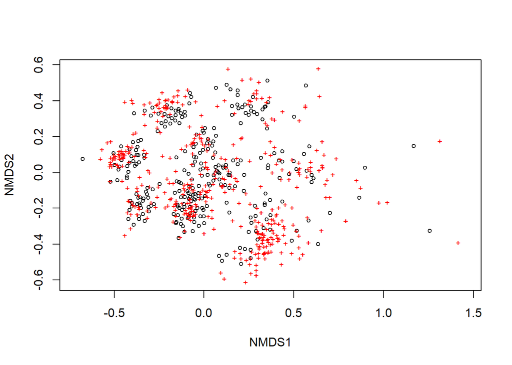

```r
plot(NMDS_bray) ### ordinary graph, just distinction in 2 colors and symbols
```

```r
# Save scores

write.table(NMDS_bray$points, "sitesR.txt", row.names=T, sep="\t")
write.table(NMDS_bray$species, "species.txt", row.names=F, sep="\t")
```

WARNING: The data sets used here are for training purposes only. The two matrices from test dataset don’t represent a realistic species composition of the vegetation types described here. We collated species # data from our personal datasets and shuffled them into the columns of the species matrix. For example, you mind find that species common in Semideciduous forest (SEMI) might instead be listed amongst Rain Forest (OMB) species.

Better NMDS graph: distinction between vegetation types (as in the following example: ssm, as, fo). You must to use 2 matrix files, one with species and another one with classification in vegetation types (e.g. if you just want to check species distribution between types) or environmental variables (e.g. soil: ph, Al…). In this example we just want to check the species distribution among vegetation types. Thus, you need the species matrix file (here it is the object “matrix”) and another one with category (here it is “matrix4”). Each row number of “matrix4” corresponds to the same row number in “matrix”. Therefore both matrices must have the same sequence and number of rows.

Note 1: again all of the these 3 matrices must have the same sequence and number of rows. Within each row you classify the soil variable value and element, or in case of vegetation the category.

Better Graph (separation among types: OMB, GAL, SEMI):

```r
matrix<- read.table("matrixspp.txt", header=T, sep="\t")
matrix[1:5,1:4] # shows only part of the data
```

```
##   abarema_brachystachya abarema_villosa acanthocladus_pulcherrimus
## 1                     0               0                          0
## 2                     0               0                          0
## 3                     0               0                          0
## 4                     0               0                          0
## 5                     0               0                          0
##   alchornea_glandulosa
## 1                    0
## 2                    0
## 3                    0
## 4                    0
## 5                    0
```

```r
matrix5<- read.table("matrixtype.txt", header=T, sep="\t")
head(matrix5) # shows by default only the first 6 rows of data
```

```
##   type codigos
## 1 OMBR     OMB
## 2 OMBR     OMB
## 3 OMBR     OMB
## 4 OMBR     OMB
## 5 OMBR     OMB
## 6 OMBR     OMB
```

```r
forest.nmds <- metaMDS(matrix, distance="bray")
```

```
## Wisconsin double standardization
## *** No convergence -- monoMDS stopping criteria:
##      1: no. of iterations >= maxit
##     19: stress ratio > sratmax
```

```r
grupo<- matrix5$codigos
grupo.nivel <- levels(grupo)
head(grupo) # shows by default only the first 6 rows of data
```

```
## [1] OMB OMB OMB OMB OMB OMB
## Levels: GAL OMB SEMI
```

```r
head(grupo.nivel) # shows by default only the first 6 rows of data
```

```
## [1] "GAL"  "OMB"  "SEMI"
```

```r
escores.nmds <- scores(forest.nmds)
head(escores.nmds, 10) # shows only the scores of the first 10 rows
```

```
##          NMDS1       NMDS2
## 1  -0.43338491  0.06702318
## 2   0.16152959 -0.07929433
## 3  -0.14601269  0.30380524
## 4   0.12447163  0.45757042
## 5  -0.05114155  0.13083438
## 6   0.34695833 -0.14847638
## 7  -0.32401926 -0.13951549
## 8   0.41282420  0.05414265
## 9  -0.47627775  0.10440796
## 10  0.03482718 -0.07052191
```

```r
forest.nmds$stress
```

```
## [1] 0.2185807
```

```r
p <- ordiplot(escores.nmds, type="n", main="Vegetation Types")
```

```
## species scores not available
```

```r
grupo.nivel
```

```
## [1] "GAL"  "OMB"  "SEMI"
```

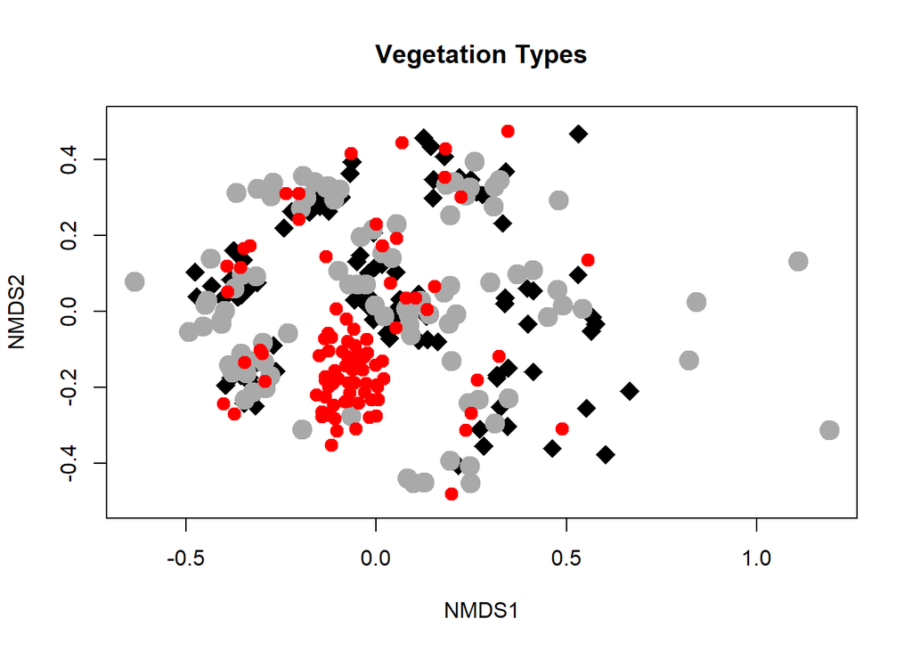

```r
points(escores.nmds[grupo=="OMB",], pch=(18), cex=2, col="black")
points(escores.nmds[grupo=="GAL",], pch=(19), cex=2, col="darkgrey")
points(escores.nmds[grupo=="SEMI",], pch=(20), cex=2, col="red")
```

#### Analysis of similarities (ANOSIM)

Basic template by “vegan”

The two matrices used here are the same as those used previously in NMDS analysis

```r
# usage:

library(vegan)

# Data

matrix<- read.table("matrixspp.txt", header=T, sep="\t")
matrix[1:5,1:4] # shows only part of the data
```

```
##   abarema_brachystachya abarema_villosa acanthocladus_pulcherrimus
## 1                     0               0                          0
## 2                     0               0                          0
## 3                     0               0                          0
## 4                     0               0                          0
## 5                     0               0                          0
##   alchornea_glandulosa
## 1                    0
## 2                    0
## 3                    0
## 4                    0
## 5                    0
```

```r
matrix5<- read.table("matrixtype.txt", header=T, sep="\t")
head(matrix5) # shows by default only the first 6 rows of data
```

```
##   type codigos
## 1 OMBR     OMB
## 2 OMBR     OMB
## 3 OMBR     OMB
## 4 OMBR     OMB
## 5 OMBR     OMB
## 6 OMBR     OMB
```

#### Analysis-ANOSIM

```r
matrix[1:5,1:4] # shows only part of the data
```

```
##   abarema_brachystachya abarema_villosa acanthocladus_pulcherrimus
## 1                     0               0                          0
## 2                     0               0                          0
## 3                     0               0                          0
## 4                     0               0                          0
## 5                     0               0                          0
##   alchornea_glandulosa
## 1                    0
## 2                    0
## 3                    0
## 4                    0
## 5                    0
```

```r
head(matrix5) # shows by default only the first 6 rows of data
```

```
##   type codigos
## 1 OMBR     OMB
## 2 OMBR     OMB
## 3 OMBR     OMB
## 4 OMBR     OMB
## 5 OMBR     OMB
## 6 OMBR     OMB
```

```r
attach(matrix5)
forest.dist <- vegdist(matrix, "bray")
forest.ano <- anosim(matrix, matrix5$codigo)
summary(forest.ano)
```

```
##
## Call:
## anosim(x = matrix, grouping = matrix5$codigo)
## Dissimilarity: bray
##
## ANOSIM statistic R: 0.09155
##       Significance: 0.001
##
## Permutation: free
## Number of permutations: 999
##
## Upper quantiles of permutations (null model):
##     90%     95%   97.5%     99%
## 0.00741 0.01019 0.01246 0.01541
##
## Dissimilarity ranks between and within classes:
##         0%     25%   50%     75%  100%     N
## Between  3 10782.0 20070 32024.0 32024 26133
## GAL      4 12251.5 22714 32024.0 32024  4278
## OMB      2 10176.5 20662 32024.0 32024  4278
## SEMI     1  3031.5 11048 22024.5 32024  4371
```

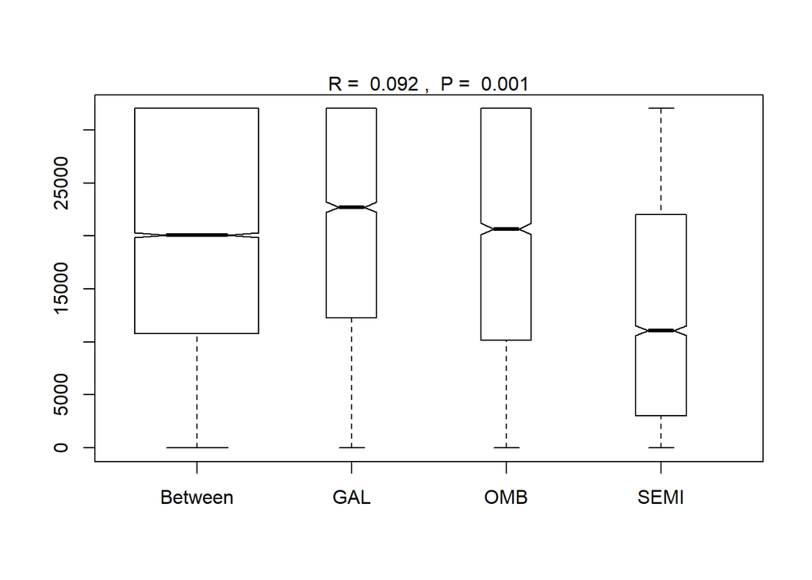

```r
plot(forest.ano)
```

```r
forest.nmds$stress
```

```
## [1] 0.2185807
```

The graph described in NMDS analysis can also be used to illustrate the result of ANOSIM.

Important: This ANOSIM using R just provides the Global R statistics and p-value, i.e. whether there are differences or not. If you need to know between which pairs there are significant differences, the most pratical and acessible way is to do ANOSIM in the “PAST” software. To do this you insert the names of the categories in the first column (grey), which corresponds to the rows , and the species’ names in the horizontal grey row, which corresponds to the columns. Your columns will contain the species’ names. In the rest of the cells are filled with the species abundance data per plot. The last step is to mark the first column with type names in different colors. Just go in edit and you’ll find how to insert different colors to specific lines. “Past” requires at least 2 different color groups to be defined. Lastly, just click on “Multivariatve” and select “ANOSIM-One way”. The output will return the Global and the pairwise values.

#### CCA (Canonical Correspondence Analysis)

CCA, also refered as constrained correspondence analysis, is one of the most commonly used multivariate analyses to model and to test effects of environmental variables (e.g. soil properties (ph, N, P, K etc) on species composition of plant communities.

```r
# install.packages("vegan")
library(vegan)

# Usage:

# Species matrix

matrix<- read.table("matrixspp.txt", header=T, sep="\t")
matrix[1:5,1:4] # shows only part of the data
```

```
##   abarema_brachystachya abarema_villosa acanthocladus_pulcherrimus
## 1                     0               0                          0
## 2                     0               0                          0
## 3                     0               0                          0
## 4                     0               0                          0
## 5                     0               0                          0
##   alchornea_glandulosa
## 1                    0
## 2                    0
## 3                    0
## 4                    0
## 5                    0
```

```r
# Environmental matrix

env<- read.table("matrixenv.txt", header=T, sep="\t")
head(env)
```

```
##    pH P  K  Ca  Mg  Al
## 1 4.5 4 39 0.1 0.1 2.6
## 2 4.5 4 45 0.1 0.1 3.3
## 3 4.4 3 39 0.2 0.1 3.2
## 4 4.2 4 44 0.2 0.1 2.2
## 5 4.0 5 36 0.2 0.1 4.1
## 6 4.3 4 28 0.1 0.1 2.1
```

```r
forest.cca <- cca(matrix ~ pH + P + K + Ca + Mg + Al, env, na.action = na.fail)
forest.cca
```

```
## Call: cca(formula = matrix ~ pH + P + K + Ca + Mg + Al, data =
## env, na.action = na.fail)
##
##                Inertia Proportion Rank
## Total         26.84694    1.00000
## Constrained    0.57015    0.02124    6
## Unconstrained 26.27679    0.97876  273
## Inertia is scaled Chi-square
## 73 species (variables) deleted due to missingness
##
## Eigenvalues for constrained axes:
##    CCA1    CCA2    CCA3    CCA4    CCA5    CCA6
## 0.13345 0.10707 0.09487 0.08878 0.07677 0.06921
##
## Eigenvalues for unconstrained axes:
##    CA1    CA2    CA3    CA4    CA5    CA6    CA7    CA8
## 0.7949 0.7109 0.6902 0.6704 0.6100 0.5536 0.5123 0.5007
## (Showing 8 of 273 unconstrained eigenvalues)
```

```r
anova(forest.cca, by="margin")
```

```
## Permutation test for cca under reduced model
## Marginal effects of terms
## Permutation: free
## Number of permutations: 999
##
## Model: cca(formula = matrix ~ pH + P + K + Ca + Mg + Al, data = env, na.action = na.fail)
##           Df ChiSquare      F Pr(>F)
## pH         1    0.1070 1.1121  0.178
## P          1    0.1046 1.0862  0.262
## K          1    0.1015 1.0546  0.325
## Ca         1    0.0974 1.0120  0.432
## Mg         1    0.0815 0.8467  0.799
## Al         1    0.1020 1.0597  0.316
## Residual 273   26.2768
```

```r
summary<- summary(forest.cca) # scores of CCA
head(summary) # shows by default only the first 6 rows of the scores
```

```
##
## Call:
## cca(formula = matrix ~ pH + P + K + Ca + Mg + Al, data = env,      na.action = na.fail)
##
## Partitioning of scaled Chi-square:
##               Inertia Proportion
## Total         26.8469    1.00000
## Constrained    0.5702    0.02124
## Unconstrained 26.2768    0.97876
##
## Eigenvalues, and their contribution to the scaled Chi-square
##
## Importance of components:
##                           CCA1     CCA2     CCA3     CCA4     CCA5
## Eigenvalue            0.133454 0.107067 0.094870 0.088783 0.076768
## Proportion Explained  0.004971 0.003988 0.003534 0.003307 0.002859
## Cumulative Proportion 0.004971 0.008959 0.012493 0.015800 0.018659
##                           CCA6     CA1     CA2     CA3     CA4     CA5
## Eigenvalue            0.069211 0.79491 0.71093 0.69017 0.67039 0.61000
## Proportion Explained  0.002578 0.02961 0.02648 0.02571 0.02497 0.02272
## Cumulative Proportion 0.021237 0.05085 0.07733 0.10303 0.12801 0.15073
##                           CA6     CA7     CA8     CA9    CA10    CA11
## Eigenvalue            0.55365 0.51231 0.50066 0.43055 0.37484 0.35749
## Proportion Explained  0.02062 0.01908 0.01865 0.01604 0.01396 0.01332
## Cumulative Proportion 0.17135 0.19043 0.20908 0.22512 0.23908 0.25240
##                          CA12    CA13    CA14    CA15    CA16    CA17
## Eigenvalue            0.33137 0.31731 0.31476 0.29647 0.29313 0.28059
## Proportion Explained  0.01234 0.01182 0.01172 0.01104 0.01092 0.01045
## Cumulative Proportion 0.26474 0.27656 0.28828 0.29932 0.31024 0.32069
##                          CA18     CA19     CA20     CA21     CA22     CA23
## Eigenvalue            0.27204 0.264399 0.257427 0.253720 0.247108 0.243790
## Proportion Explained  0.01013 0.009848 0.009589 0.009451 0.009204 0.009081
## Cumulative Proportion 0.33083 0.340676 0.350265 0.359715 0.368920 0.378000
##                           CA24     CA25     CA26    CA27     CA28     CA29
## Eigenvalue            0.243745 0.240429 0.229699 0.22041 0.216962 0.215906
## Proportion Explained  0.009079 0.008956 0.008556 0.00821 0.008081 0.008042
## Cumulative Proportion 0.387079 0.396035 0.404591 0.41280 0.420882 0.428924
##                           CA30     CA31    CA32    CA33     CA34     CA35
## Eigenvalue            0.212313 0.211601 0.21100 0.20539 0.202015 0.200763
## Proportion Explained  0.007908 0.007882 0.00786 0.00765 0.007525 0.007478
```

[output cut: 236 more lines]

```
## row4  1.5712  0.61372 -0.46802  0.08159 0.5547 -0.227517
## row5  0.5161 -0.62360  1.33765 -0.91375 0.2887  1.930741
## row6  1.4922 -0.40025 -0.81149 -0.48078 0.3170  0.009357
## ....
##
##
## Biplot scores for constraining variables
##
##        CCA1     CCA2     CCA3     CCA4     CCA5    CCA6
## pH -0.50007 -0.19882 -0.19379 -0.41096  0.06805 -0.7066
## P   0.52640 -0.05314  0.65806 -0.49648  0.10292 -0.1730
## K  -0.32880  0.82533  0.37257 -0.07746  0.04001 -0.2536
## Ca -0.11852  0.11749  0.72741  0.22325 -0.32501 -0.5362
## Mg -0.03656  0.30274  0.07982 -0.27226 -0.89713 -0.1472
## Al -0.39741  0.31070  0.40749 -0.22859  0.04560  0.7247
```

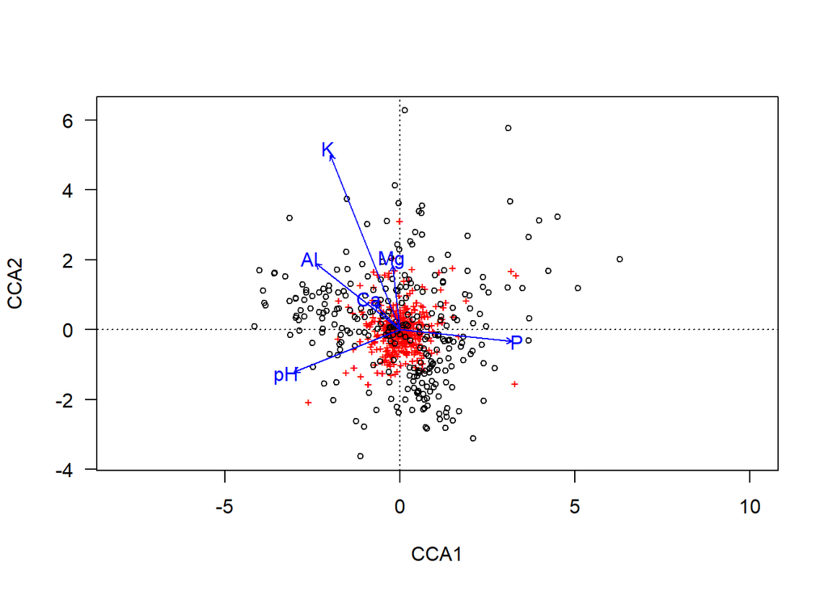

```r
# ordinary plot
x11(width=12, height=12)
plot(forest.cca, las=1)
```

```r
# dev.off()
```

#### PCA (Principal Component Analysis

PCA is a method commonly used to separate variables (e.g environmental data, such as soil conditions) in ordination before submitting them to further analysis.

To execute the PCA in the example below, we use the function rda, though other functions such as prcomp or princomp can also be used to calculate PCA. It’s important to correctly interpret the PCA output before trying to understand values returned by the function “PCAsignificance” and the command “PC1.exp”, which are explained below. The command PC1.exp shows the percentage of explanation of each axis. In the function “PCAsignificance” the result named “percentage of variance” shows the percentage of variation explained by axis 1. You can access further information about this, and other values, by requesting R help for this function by writing: ?PCAsignificance.

The output of rda, v, contains the scores of the “species” (here: soil variables) and sites on the ordination axes. These are not the same as the correlations of variables with the axes.

```r
# install.packages("vegan")

library(vegan) # rda function for PCA analysis

# Environmental matrix
env<- read.table("matrixenv.txt", header=T, sep="\t")
head(env)
```

```
##    pH P  K  Ca  Mg  Al
## 1 4.5 4 39 0.1 0.1 2.6
## 2 4.5 4 45 0.1 0.1 3.3
## 3 4.4 3 39 0.2 0.1 3.2
## 4 4.2 4 44 0.2 0.1 2.2
## 5 4.0 5 36 0.2 0.1 4.1
## 6 4.3 4 28 0.1 0.1 2.1
```

```r
# Usage:

pca.env <- rda(env, scale=TRUE) # scale = TRUE - to standardize the data
pca.env
```

```
## Call: rda(X = env, scale = TRUE)
##
##               Inertia Rank
## Total               6
## Unconstrained       6    6
## Inertia is correlations
##
## Eigenvalues for unconstrained axes:
##    PC1    PC2    PC3    PC4    PC5    PC6
## 1.9853 1.4433 1.0506 0.7259 0.5413 0.2536
```

```r
summary<- summary(pca.env)
head(summary) # shows by default only the first 6 rows of the scores
```

```
##
## Call:
## rda(X = env, scale = TRUE)
##
## Partitioning of correlations:
##               Inertia Proportion
## Total               6          1
## Unconstrained       6          1
##
## Eigenvalues, and their contribution to the correlations
##
## Importance of components:
##                          PC1    PC2    PC3    PC4     PC5     PC6
## Eigenvalue            1.9853 1.4433 1.0506 0.7259 0.54130 0.25355
## Proportion Explained  0.3309 0.2406 0.1751 0.1210 0.09022 0.04226
## Cumulative Proportion 0.3309 0.5714 0.7465 0.8675 0.95774 1.00000
##
## Scaling 2 for species and site scores
## * Species are scaled proportional to eigenvalues
## * Sites are unscaled: weighted dispersion equal on all dimensions
## * General scaling constant of scores:  6.396448
##
##
## Species scores
##
##        PC1     PC2     PC3       PC4     PC5      PC6
## pH -0.7012  2.0436 -0.3792  0.883221  1.0642  0.30809
## P  -0.9181 -0.4401  2.2376 -0.225144  0.8270 -0.20217
## K  -2.1470 -0.4973 -0.5432  0.972407 -0.2224 -0.81988
## Ca -2.1582  0.4553  0.6081 -0.001057 -1.0408  0.70784
## Mg -1.6190  0.1906 -0.9777 -1.712833  0.5125 -0.09719
## Al -0.5612 -2.2319 -0.6268  0.489924  0.6923  0.64071
##
##
## Site scores (weighted sums of species scores)
##
##         PC1       PC2      PC3      PC4     PC5     PC6
## sit1 0.2332  0.089598  0.17463  0.08095  0.4550 -0.2855
## sit2 0.1368 -0.145176  0.06386  0.24593  0.6126 -0.1015
## sit3 0.1862 -0.107166 -0.08787  0.13652  0.1706  0.2740
## sit4 0.1762  0.005016  0.30162 -0.10225 -0.1222 -0.5942
## sit5 0.1254 -0.741146  0.40371 -0.10187  0.3741  0.3728
## sit6 0.4021  0.131917  0.32129 -0.24087  0.1643 -0.3517
## ....
```

If you want to test for the signifance of PCA, you can either use the function PCAsignificance of the package BiodiversityR (e.g. PCAsignificance(pca.env, axes=6)) or to compute an anova under a rda.

```r
(av <- pca.env$CA$eig) # av - inspects the eigenvalues. The sum of eigenvalues
```

```
##       PC1       PC2       PC3       PC4       PC5       PC6
## 1.9852662 1.4433273 1.0506311 0.7259281 0.5412958 0.2535515
```

```r
                       # represent the total percentage of explanation assigned
                       # to each axis.
                       # pca.env$CA$":Relationship of each environmental variable
                       # with the axes.The closer the result is to 1, the larger
                       # the association with the positive or negative axis, respectively.
```

```r
sum.av <- sum(av)
PC1.exp <- 100*(av[1]/sum(av))  # calculate the percentage of explanation of
PC1.exp                         # each axis. Here it shows the percentage of the
```

```
##      PC1
## 33.08777
```

```r
round(PC1.exp, 2) # You can choose how many decimals after the point you would
```

```
##   PC1
## 33.09
```

```r
                  # like to keep. Here it is 2.
```

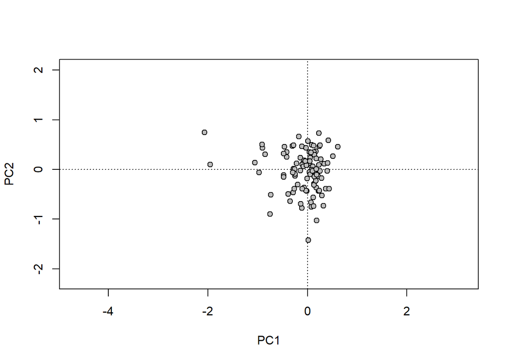

```r
# Simple gragh

x11(width=12, height=12)
plot(pca.env, type="n")
points(pca.env, display = "sites", col=1, pch=21, cex=1, bg="grey")
```

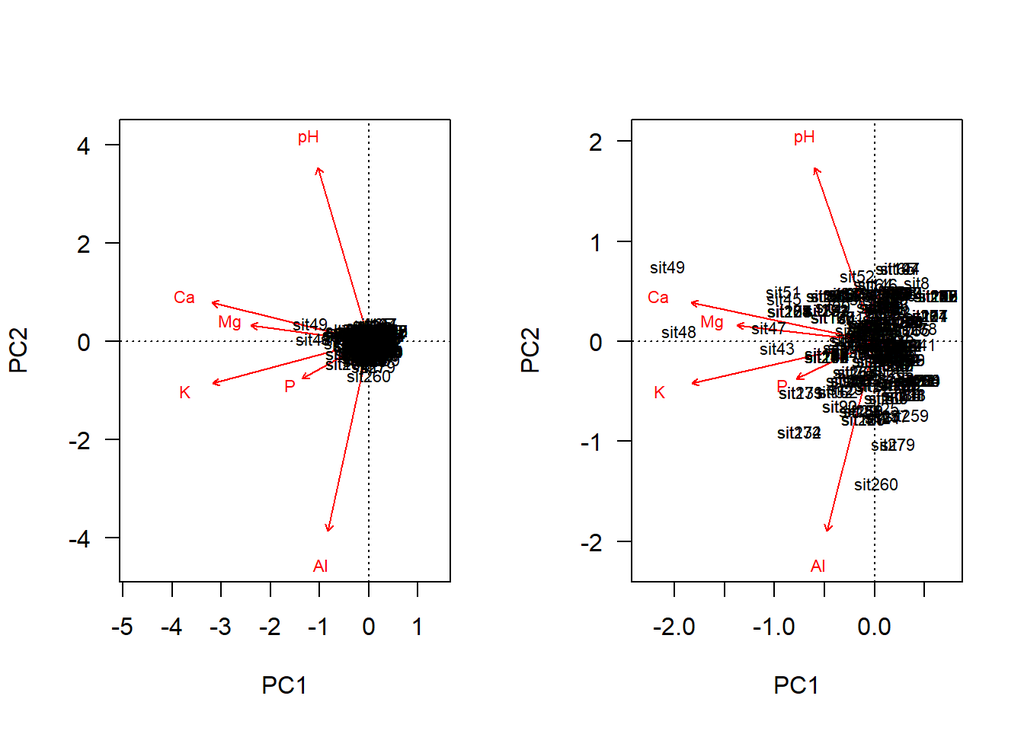

```r
# Biplot graph

par(mfrow=c(1,2))
plot1 <- biplot(pca.env, scaling=1, type="text", las=1) # sites scaled by
                                                        # eigenvalues
plot2 <- biplot(pca.env, scaling=2, type="text", las=1) # species scaled by
```

```r
                                                        # eigenvalues
# dev.off()
```

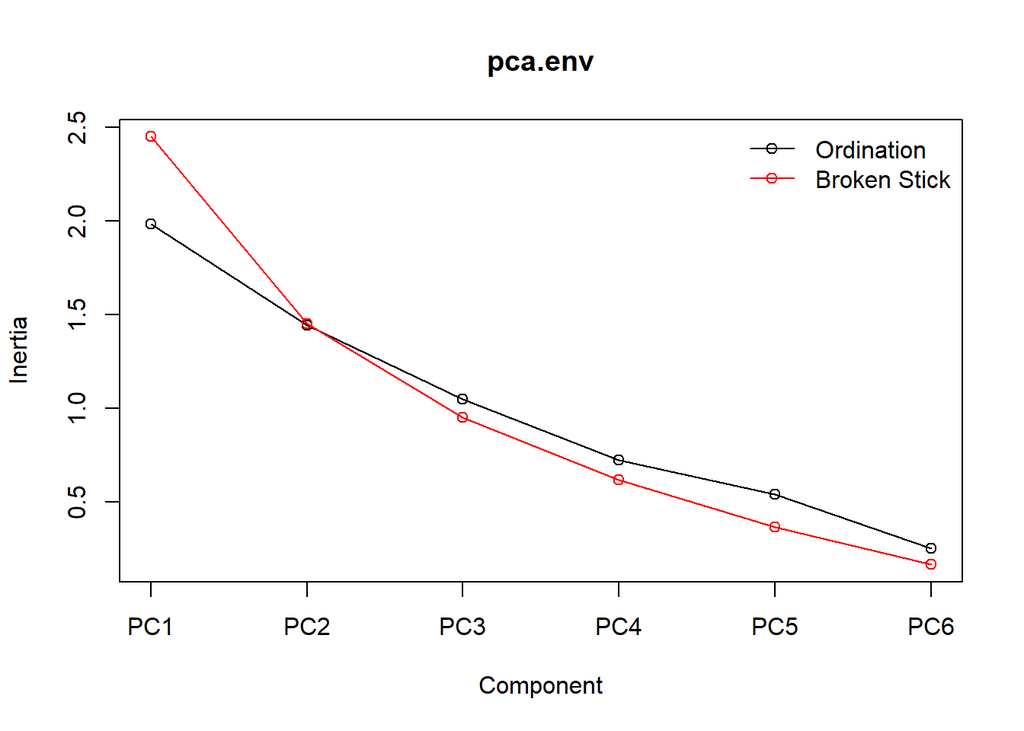

```r
# Screeplots - select axes with values from the ordination that are larger
# than the expected value under the Broken stick criteria.

screeplot(pca.env, bstick = TRUE, type = "lines")
```

#### Analysis of Indicator Species (INDVAL)

The association index named IndVal computed with the function “multipatt” of the package “indicspecies” is generated by combinations of the input clusters and comparison of each combination with the matrix species. Thus, each species receives the combination with the highest association value and the best matching patterns are tested for statistical significance of the associations. Thus this analysis is useful to indicate species that can be used to gather information about specific characteristics of habitats or environment (e.g. forest types; soil types; drought or wetter sites).

The name “type” within the command below refers to the categorical variable in the forest type matrix (matrixtype.txt). “codigos” are labels given to abbreviate forest type names: OMB = Rain (Ombrophilous) Forest; GAL = Gallery Forest and SEMI = Semideciduos forest.

```r
# install.packages("indicspecies")

library(indicspecies)

# Species matrix
matrixspp<- read.table("matrixspp.txt", header=T, sep="\t")
matrixspp[1:5,1:4] # shows only part of the data
```

```
##   abarema_brachystachya abarema_villosa acanthocladus_pulcherrimus
## 1                     0               0                          0
## 2                     0               0                          0
## 3                     0               0                          0
## 4                     0               0                          0
## 5                     0               0                          0
##   alchornea_glandulosa
## 1                    0
## 2                    0
## 3                    0
## 4                    0
## 5                    0
```

```r
# Vegetation type
type <- read.table("matrixtype.txt", header=T)
head(type)
```

```
##   type codigos
## 1 OMBR     OMB
## 2 OMBR     OMB
## 3 OMBR     OMB
## 4 OMBR     OMB
## 5 OMBR     OMB
## 6 OMBR     OMB
```

```r
wetpt = multipatt(matrixspp, type$codigos) # Runs the combination analysis
                                  # using IndVal.g as statistic
head(wetpt, 3) # shows by only the first 3 rows of the scores
```

[output not shown]

```r
summary(wetpt) # Lists those species with significant association to one combination
```

```
##
##  Multilevel pattern analysis
##  ---------------------------
##
##  Association function: IndVal.g
##  Significance level (alpha): 0.05
##
##  Total number of species: 532
##  Selected number of species: 62
##  Number of species associated to 1 group: 49
##  Number of species associated to 2 groups: 13
##
##  List of species associated to each combination:
##
##  Group GAL  #sps.  12
##                         stat p.value
## callisthene_major      0.360   0.005 **
## allagoptera_caudescens 0.302   0.005 **
## guazuma_ulmifolia      0.292   0.005 **
## alibertia_edulis       0.280   0.010 **
## miconia_cabucu         0.260   0.045 *
## dilodendron_bipinnatum 0.245   0.010 **
## protium_warmingiana    0.239   0.015 *
## diospyros_brasiliensis 0.239   0.005 **
## miconia_latecrenata    0.238   0.010 **
## parinari_parvifolia    0.232   0.005 **
## callisthene_minor      0.224   0.025 *
## psidium_oblongatum     0.207   0.015 *
##
##  Group OMB  #sps.  8
##                                  stat p.value
## licania_kunthiana               0.417   0.005 **
## phyllostemonodaphne_geminiflora 0.260   0.005 **
## styrax_ferrugineus              0.254   0.010 **
## ixora_gardneriana               0.232   0.025 *
## deguelia_hatschbachii           0.224   0.030 *
## virola_officinalis              0.223   0.045 *
## myrciaria_floribunda            0.217   0.015 *
## licania_spicata                 0.180   0.050 *
##
```

[output cut: 40 more lines]

```
## eschweilera_ovata        0.292   0.030 *
## terminalia_glabrescens   0.264   0.015 *
## ocotea_divaricata        0.220   0.050 *
## tabebuia_serratifolia    0.220   0.030 *
##
##  Group GAL+SEMI  #sps.  1
##                   stat p.value
## miconia_albicans 0.243    0.04 *
##
##  Group OMB+SEMI  #sps.  2
##                  stat p.value
## aniba_firmula   0.472   0.010 **
## ocotea_dispersa 0.317   0.025 *
## ---
## Signif. codes:  0 '***' 0.001 '**' 0.01 '*' 0.05 '.' 0.1 ' ' 1
```

#### Permutational Analysis of variance (PERMANOVA)

PERMANOVA is a non-parametric multivariate statistical test used to compare groups of objects based on any measure of distance. Commonly this analysis is used to compare taxon in samples where the groups of samples are compared.

```r
library(vegan)
library(permute)
library(lattice)

spp <- read.table("matrixspp.txt", header=T)
spp[1:5,10:13]
```

```
##   allophylus_racemosus alseis_floribunda amaioua_guianensis
## 1                    0                 0                  1
## 2                    0                 0                  0
## 3                    0                 0                  0
## 4                    0                 0                  0
## 5                    0                 0                  0
##   amaioua_intermedia
## 1                  0
## 2                  0
## 3                  0
## 4                  0
## 5                  0
```

```r
log(spp+1)->spp2
spp2[1:5,10:13]
```

```
##   allophylus_racemosus alseis_floribunda amaioua_guianensis
## 1                    0                 0          0.6931472
## 2                    0                 0          0.0000000
## 3                    0                 0          0.0000000
## 4                    0                 0          0.0000000
## 5                    0                 0          0.0000000
##   amaioua_intermedia
## 1                  0
## 2                  0
## 3                  0
## 4                  0
## 5                  0
```

Usage:

Testing for species composition over different forest types: the name “type” within the command below is the categorical variable in the forest type matrix (matrixtype.txt). “codigos” are just labels given to abbreviate forest typenames: OMB = Rain (Ombrophilous) Forest; GAL = Gallery Forest and SEMI = Semideciduos forest.

```r
type<- read.table("matrixtype.txt", header=T, sep="\t")
head(type)
```

```
##   type codigos
## 1 OMBR     OMB
## 2 OMBR     OMB
## 3 OMBR     OMB
## 4 OMBR     OMB
## 5 OMBR     OMB
## 6 OMBR     OMB
```

```r
adonis(spp2 ~ codigos, data=type, permutations=999) -> perma.result1
perma.result1
```

```
##
## Call:
## adonis(formula = spp2 ~ codigos, data = type, permutations = 999)
##
## Permutation: free
## Number of permutations: 999
##
## Terms added sequentially (first to last)
##
##            Df SumsOfSqs MeanSqs F.Model      R2 Pr(>F)
## codigos     2     5.283 2.64162  6.5743 0.04532  0.001 ***
## Residuals 277   111.302 0.40181         0.95468
## Total     279   116.585                 1.00000
## ---
## Signif. codes:  0 '***' 0.001 '**' 0.01 '*' 0.05 '.' 0.1 ' ' 1
```

Testing for soil influence in the tree species abundance: the names in the right side of the formula regard the soil variables contained in the environmental matrix (“matrixenv.txt”). The category “types” regard the forest type (OMB, GAL and SEMI).

```r
env <- read.table("matrixenv.txt", header=T)
head(env)
```

```
##    pH P  K  Ca  Mg  Al
## 1 4.5 4 39 0.1 0.1 2.6
## 2 4.5 4 45 0.1 0.1 3.3
## 3 4.4 3 39 0.2 0.1 3.2
## 4 4.2 4 44 0.2 0.1 2.2
## 5 4.0 5 36 0.2 0.1 4.1
## 6 4.3 4 28 0.1 0.1 2.1
```

```r
adonis(spp2 ~ pH + P + K + Ca + Mg + Al, data=env, permutations=999)-> perm.result
perm.result # Result to permanova pseudo-F, R2 e p.
```

```
##
## Call:
## adonis(formula = spp2 ~ pH + P + K + Ca + Mg + Al, data = env,      permutations = 999)
##
## Permutation: free
## Number of permutations: 999
##
## Terms added sequentially (first to last)
##
##            Df SumsOfSqs MeanSqs F.Model      R2 Pr(>F)
## pH          1     0.345 0.34542 0.82775 0.00296  0.703
## P           1     0.540 0.54033 1.29483 0.00463  0.152
## K           1     0.506 0.50551 1.21140 0.00434  0.193
## Ca          1     0.377 0.37685 0.90306 0.00323  0.587
## Mg          1     0.294 0.29425 0.70513 0.00252  0.874
## Al          1     0.600 0.60038 1.43874 0.00515  0.076 .
## Residuals 273   113.923 0.41730         0.97716
## Total     279   116.585                 1.00000
## ---
## Signif. codes:  0 '***' 0.001 '**' 0.01 '*' 0.05 '.' 0.1 ' ' 1
```

#### RECOMMENDED READING

#### Highlight:

GOTELLI, N.J.; ELLISON, A.M. A Primer of Ecological Statistics. Sinauer Associates Publishers, 2004. Version in Portuguese: GOTELLI, N.J.; ELLISON, A.M. Princípios de Estatística em Ecologia. Porto Alegre: Artmed, 2011. 527 p.

CRAWLEY, M.J. The R Book: Second Edtion. Chichester: Imperial College London at Silwood Park, John Wiley & Sons Ltd., 2012. 1051p.

BORCARD, D.; GILLET, F.; LEGENDRE, P. Numerical ecology with R. New York: Springer, 2011. 306 p.

FORTIN, M. J.; DALE, M. Spatial analysis: a guide for ecologists. Cambridge: Cambridge University, 2005. 365 p.

HINKLE, D.E.; WIERSMA, W. JURS, S.G. Applied Statistics for the Behavioral Sciences. 5th ed. Boston: Houghton Mifflin, 2003. 756 p.

LEGENDRE, P.; LEGENDRE, L. Numerical ecology. Third English edition. Amsterdam: Elsevier Science, 2012. 1006 p.

#### Complementary:

BEGON’S text book is highly recommendable reading on sampling design and statistical analysis in ecological studies (e.g. distribution, population growth, behaviour) of plants and animals.

BEGON, M.; TOWNSEND, C.R.; HARPER, J.L. Ecology: From Individuals to Ecosystems, 4th Edition. Wiley-Blackwell, 2005. 750 pages. Version in Portuguese: BEGON, M.; TOWNSEND, C.R.; HARPER, J.L. Ecologia: de indivíduos a ecossistemas. 4 ed. Porto Alegre: Artmed, 2007. 752 p.